# project

## Variable 161

```r
head(data$x161)
```

```
## [1] 0 0 0 0 0 0
```

```r
## Summary of the data
summary(data$x161)
```

```
##    Min. 1st Qu.  Median    Mean 3rd Qu.    Max.
## 0.00000 0.00000 0.00000 0.02787 0.00000 1.00000
```

##Here we found that mean and median are not pretty close and we can say that the distribution of the variable is not approximately normal

##Missing Values: ##There are no missing values

##Description of the data

```r
#install.packages("psych")

describe(data$x161)
```

```
##    vars     n mean   sd median trimmed mad min max range skew kurtosis se
## X1    1 1e+05 0.03 0.16      0       0   0   0   1     1 5.74    30.91  0
```

## Here the kurtosis is very high positive hence there is large data in tail

```r
table(data$x161)
```

```
##
##     0     1
## 97213  2787
```

```r
str(data$x161)
```

```
##  int [1:100000] 0 0 0 0 0 0 0 0 0 0 ...
```

```r
class(data$x161)
```

```
## [1] "integer"
```

## here the all values in integer

```r
##Total number of values excluding NA
NROW(data[which(data$x161<=2),])
```

```
## [1] 100000
```

##i.e;., 100%

##Now visualize the statistics ##Histogram

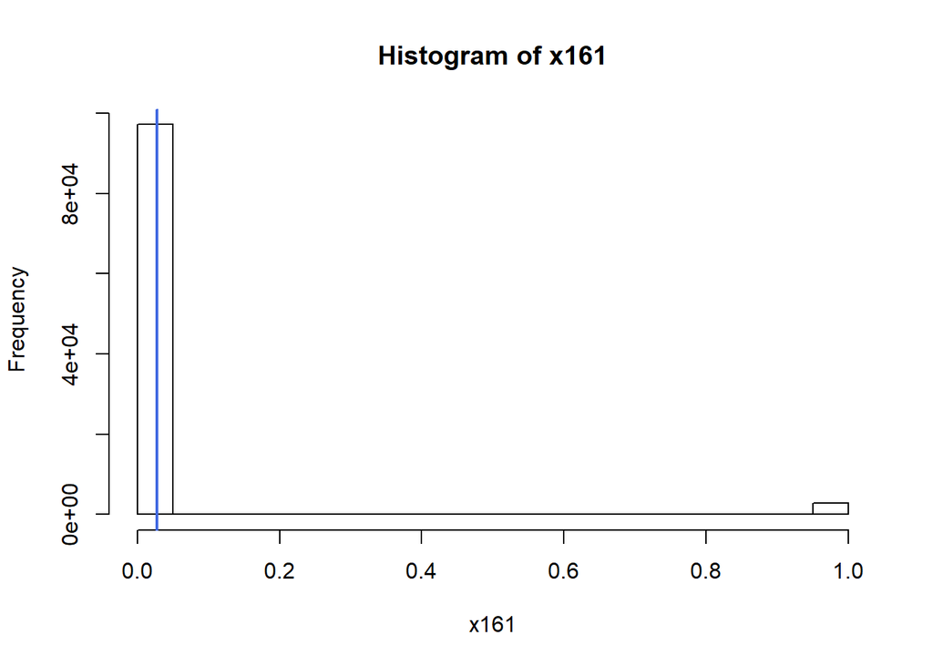

```r
hist(data$x161,
    main = "Histogram of x161",
    xlab = "x161")
abline(v =mean(data$x161, na.rm = TRUE),col = "royalblue",
lwd = 2)
```

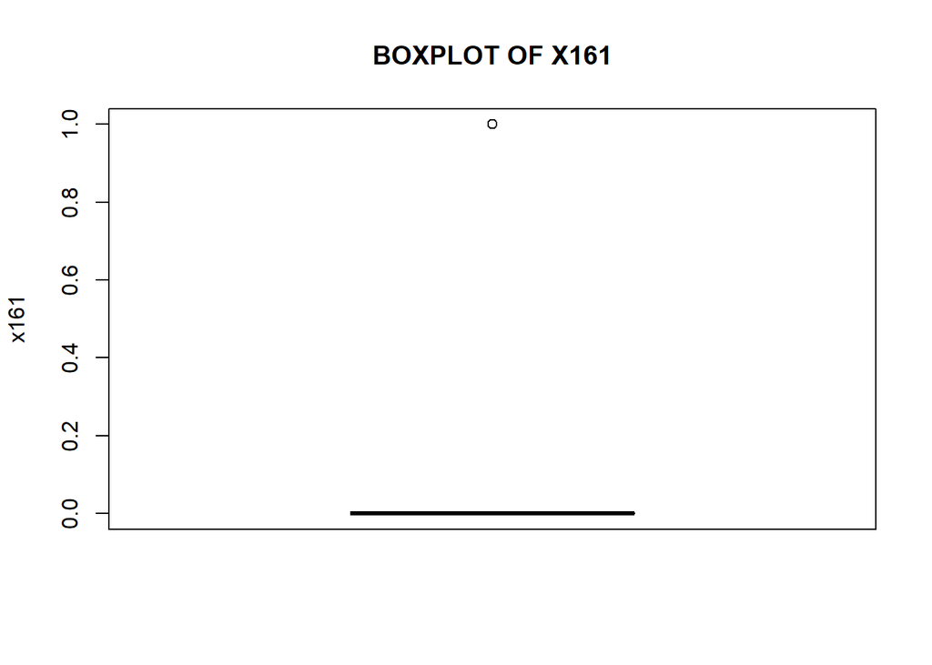

```r
##Boxplot
boxplot(data$x161,
       main = toupper("Boxplot of x161"),
       ylab = "x161",
       col = "blue")
```

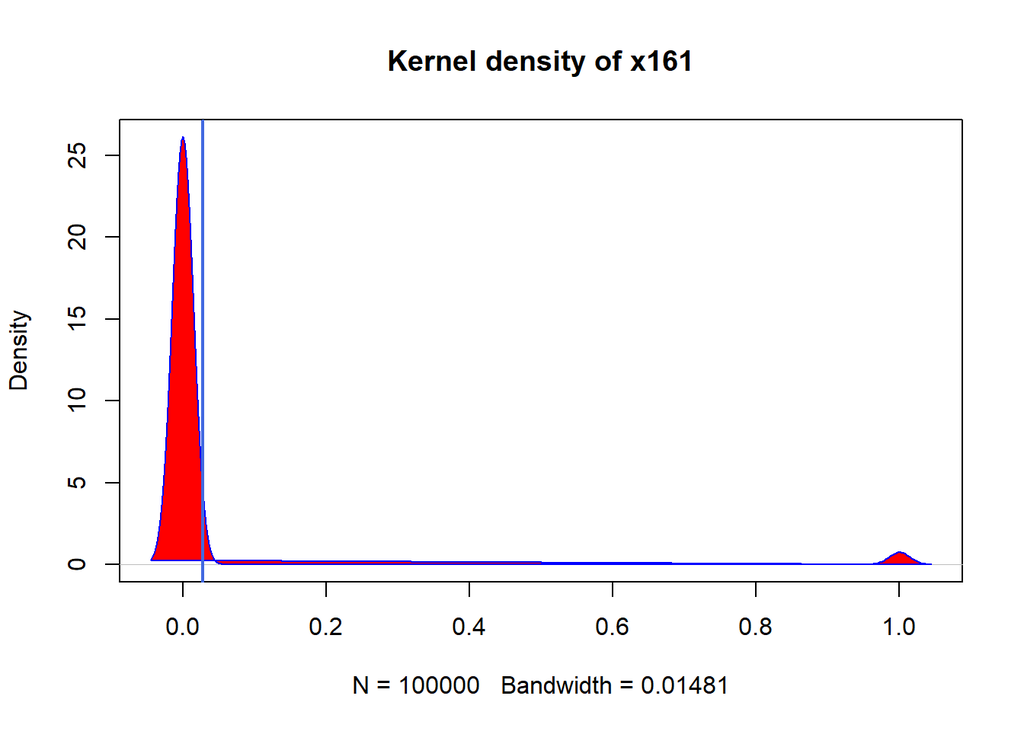

```r
##Density Plot
d <- density(data$x161, na.rm = TRUE)
plot(d, main = "Kernel density of x161")
polygon(d, col = "red", border = "blue")
abline(v =mean(data$x161, na.rm = TRUE),col = "royalblue",
lwd = 2)
```

## Obervation ## From the above graphs and stats i observed that 100% are below 2

## There is positive skewness in the data. There are no missing values. This variable have descrete binomial values.

## Variable 162

```r
head(data$x162)
```

```
## [1] NA  1 NA NA NA NA
```

```r
## Summary of the data
summary(data$x162)
```

```
##    Min. 1st Qu.  Median    Mean 3rd Qu.    Max.    NA's
##    1.00    1.00    1.00    1.33    1.00    9.00   66481
```

##Here we found that mean and median are not pretty close and we can say that the distribution of the variable is not approximately normal

##Missing Values: ##There are 67% missing values

##Description of the data

```r
data$x162 <- NULL
```

## Variable 163

```r
head(data$x163)
```

```
## [1] 0 0 0 0 0 0
```

```r
## Summary of the data
summary(data$x163)
```

```
##     Min.  1st Qu.   Median     Mean  3rd Qu.     Max.
##  0.00000  0.00000  0.00000  0.07722  0.00000 12.00000
```

##Here we found that mean and median are not pretty close and we can say that the distribution of the variable is not approximately normal

##Missing Values: ##There are no missing values

##Description of the data

```r
#install.packages("psych")

describe(data$x163)
```

```
##    vars     n mean   sd median trimmed mad min max range skew kurtosis se
## X1    1 1e+05 0.08 0.47      0       0   0   0  12    12 7.54    67.37  0
```

## Here the kurtosis is very high positive hence there is large data in tail

```r
table(data$x163)
```

```
##
##     0     1     2     3     4     5     6     7     8     9    12
## 96534  1343   840   626   568    32    26    20     9     1     1
```

```r
str(data$x163)
```

```
##  int [1:100000] 0 0 0 0 0 0 0 0 0 1 ...
```

```r
class(data$x163)
```

```
## [1] "integer"
```

## here the all values in integer

```r
##Total number of values excluding NA
NROW(data[which(data$x163<=2),])
```

```
## [1] 98717
```

```r
NROW(data[which(data$x163<=5),])
```

```
## [1] 99943
```

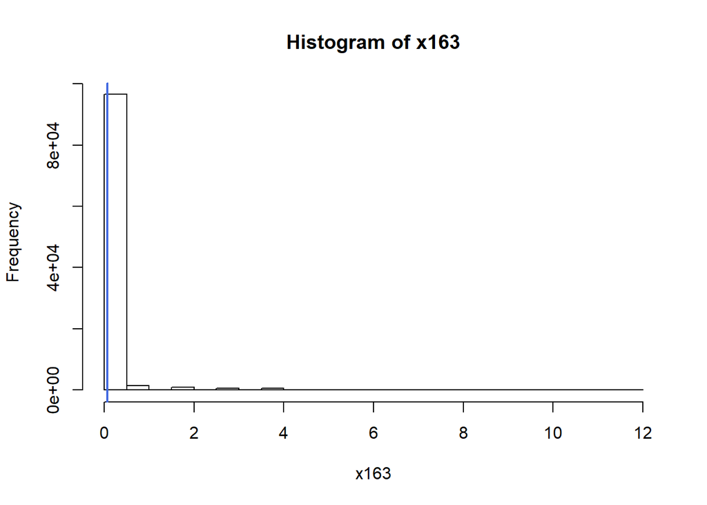

```r
##Now visualize the statistics
##Histogram

hist(data$x163,
    main = "Histogram of x163",
    xlab = "x163")
abline(v =mean(data$x163, na.rm = TRUE),col = "royalblue",
lwd = 2)
```

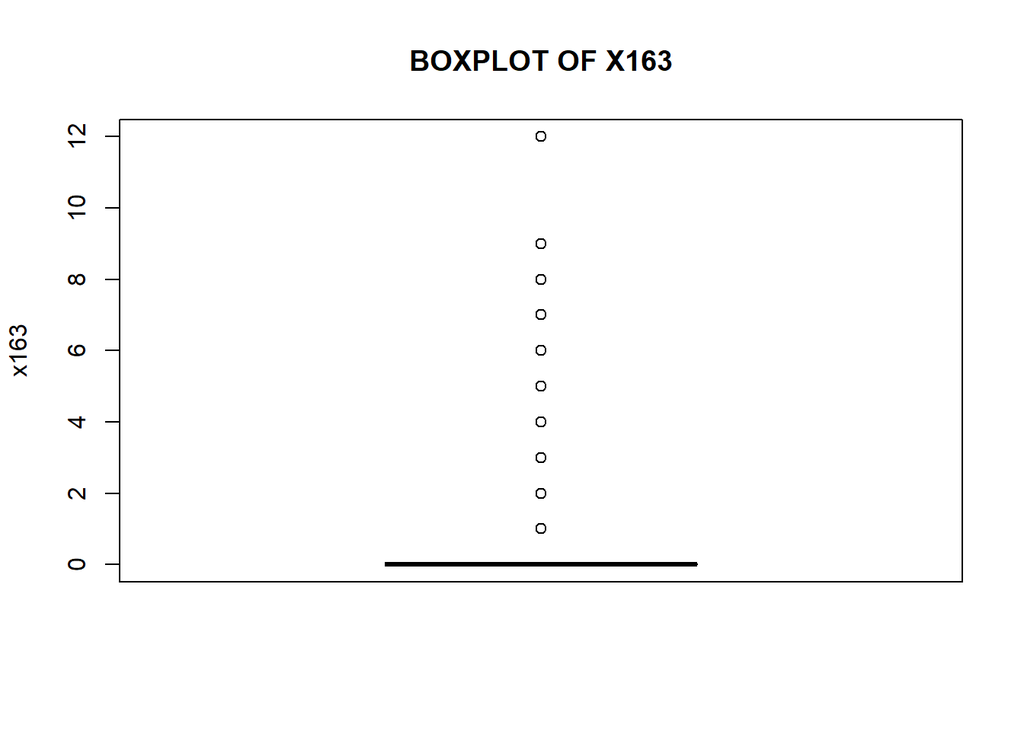

```r
##Boxplot
boxplot(data$x163,
       main = toupper("Boxplot of x163"),
       ylab = "x163",
       col = "blue")
```

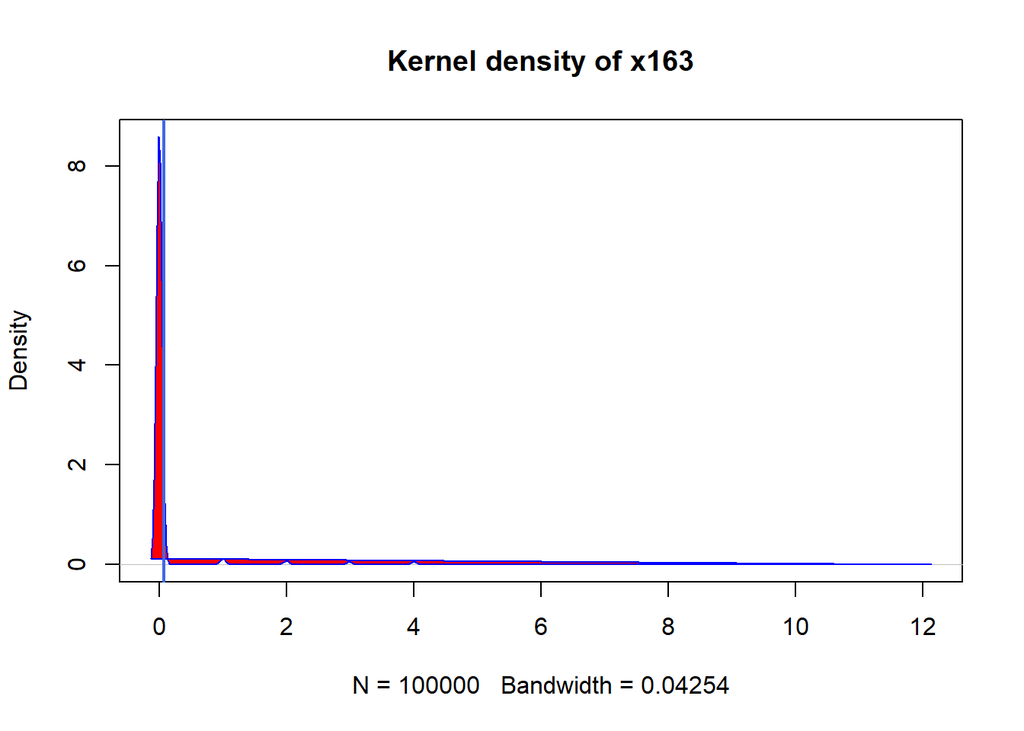

```r
##Density Plot
d <- density(data$x163, na.rm = TRUE)
plot(d, main = "Kernel density of x163")
polygon(d, col = "red", border = "blue")
abline(v =mean(data$x163, na.rm = TRUE),col = "royalblue",
lwd = 2)
```

## There is positive skewness in the data. There are no missing values. This variable have descrete values.

## Variable 164

```r
head(data$x164)
```

```
## [1] 0 0 0 0 0 0
```

```r
## Summary of the data
summary(data$x164)
```

```
##    Min. 1st Qu.  Median    Mean 3rd Qu.    Max.
##  0.0000  0.0000  0.0000  0.1558  0.0000 39.0000
```

##Here we found that mean and median are not pretty close and we can say that the distribution of the variable is not approximately normal

##Missing Values: ##There are no missing values

##Description of the data

```r
#install.packages("psych")

describe(data$x164)
```

```
##    vars     n mean   sd median trimmed mad min max range skew kurtosis se
## X1    1 1e+05 0.16 0.95      0       0   0   0  39    39 8.66   107.09  0
```

## Here the kurtosis is very high positive hence there is large data in tail

```r
table(data$x164)
```

```
##
##     0     1     2     3     4     5     6     7     8     9    10    11
## 95590  1381   780   568   411   317   263   199   162   136   126    11
##    12    13    14    15    16    17    18    19    20    39
##    15    11     7     8     4     2     2     3     3     1
```

```r
str(data$x164)
```

```
##  int [1:100000] 0 0 0 0 0 0 0 0 0 3 ...
```

```r
class(data$x164)
```

```
## [1] "integer"
```

## here the all values in integer

```r
##Total number of values excluding NA
NROW(data[which(data$x164<=2),])
```

```
## [1] 97751
```

```r
NROW(data[which(data$x164<=5),])
```

```
## [1] 99047
```

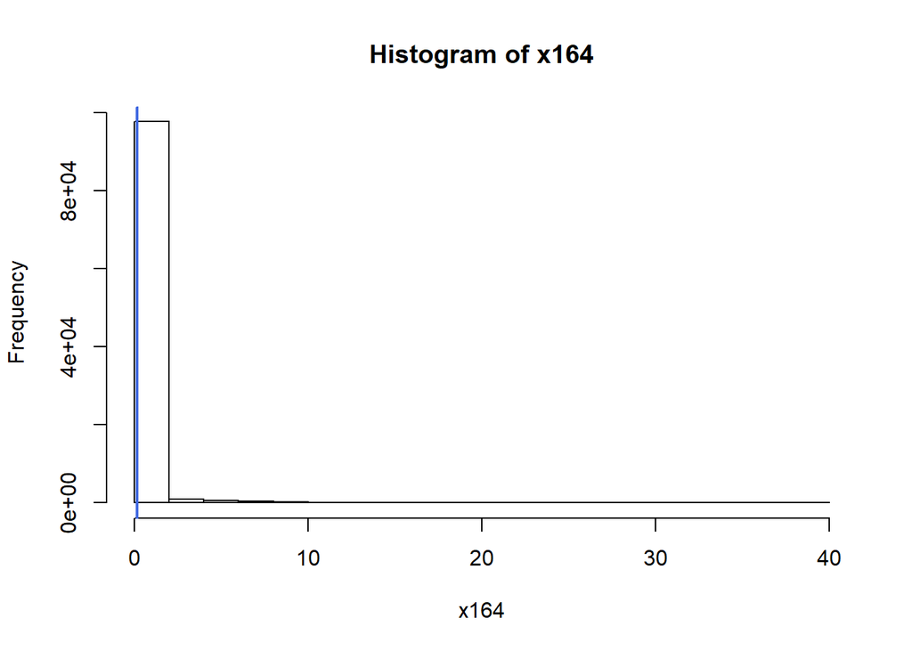

```r
##Now visualize the statistics
##Histogram

hist(data$x164,
    main = "Histogram of x164",
    xlab = "x164")
abline(v =mean(data$x164, na.rm = TRUE),col = "royalblue",
lwd = 2)
```

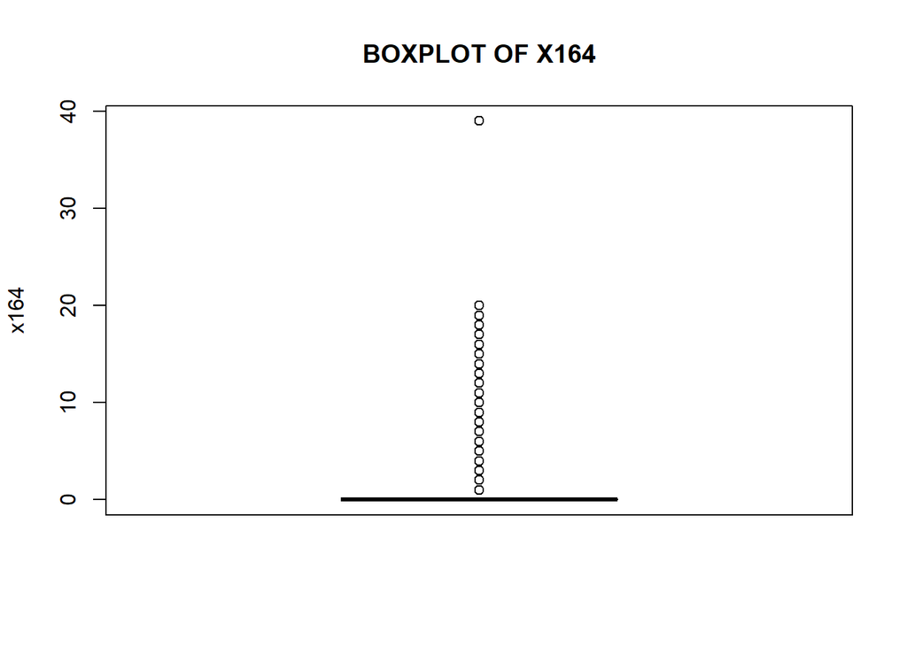

```r
##Boxplot
boxplot(data$x164,
       main = toupper("Boxplot of x164"),
       ylab = "x164",
       col = "blue")
```

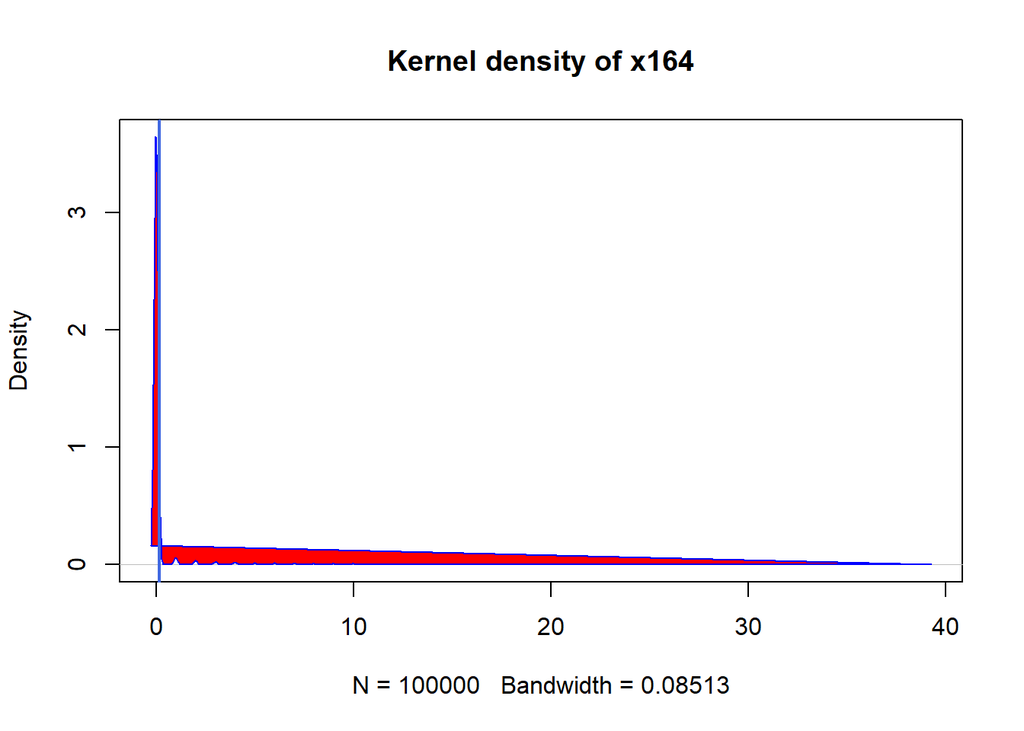

```r
##Density Plot
d <- density(data$x164, na.rm = TRUE)
plot(d, main = "Kernel density of x164")
polygon(d, col = "red", border = "blue")
abline(v =mean(data$x164, na.rm = TRUE),col = "royalblue",
lwd = 2)
```

## There is positive skewness in the data. There are no missing values. This variable have descrete values.

## Variable 165

```r
head(data$x165)
```

```
## [1] 0 0 0 0 0 0
```

```r
## Summary of the data
summary(data$x165)
```

```
##    Min. 1st Qu.  Median    Mean 3rd Qu.    Max.
##  0.0000  0.0000  0.0000  0.2641  0.0000 41.0000
```

##Here we found that mean and median are not pretty close and we can say that the distribution of the variable is not approximately normal

##Missing Values: ##There are no missing values

##Description of the data

```r
#install.packages("psych")

describe(data$x165)
```

```
##    vars     n mean   sd median trimmed mad min max range skew kurtosis
## X1    1 1e+05 0.26 1.62      0       0   0   0  41    41 8.92    99.92
##      se
## X1 0.01
```

## Here the kurtosis is very high positive hence there is large data in tail

```r
table(data$x165)
```

```
##
##     0     1     2     3     4     5     6     7     8     9    10    11
## 94829  1448   739   552   423   348   268   196   188   144   137   115
##    12    13    14    15    16    17    18    19    20    21    22    24
##    82   101    83    61    54    49    31    34    37    22    31     6
##    25    26    27    28    29    30    31    32    33    34    35    37
##     2     4     1     3     1     1     1     1     1     2     1     1
##    38    40    41
##     1     1     1
```

```r
str(data$x165)
```

```
##  int [1:100000] 0 0 0 0 0 0 0 0 0 3 ...
```

```r
class(data$x165)
```

```
## [1] "integer"
```

## here the all values in integer

```r
##Total number of values excluding NA
NROW(data[which(data$x165<=2),])
```

```
## [1] 97016
```

```r
NROW(data[which(data$x165<=5),])
```

```
## [1] 98339
```

##i.e;.,98%

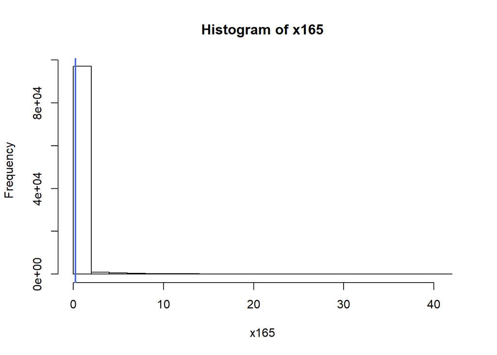

```r
##Now visualize the statistics
##Histogram

hist(data$x165,
    main = "Histogram of x165",
    xlab = "x165")
abline(v =mean(data$x165, na.rm = TRUE),col = "royalblue",
lwd = 2)
```

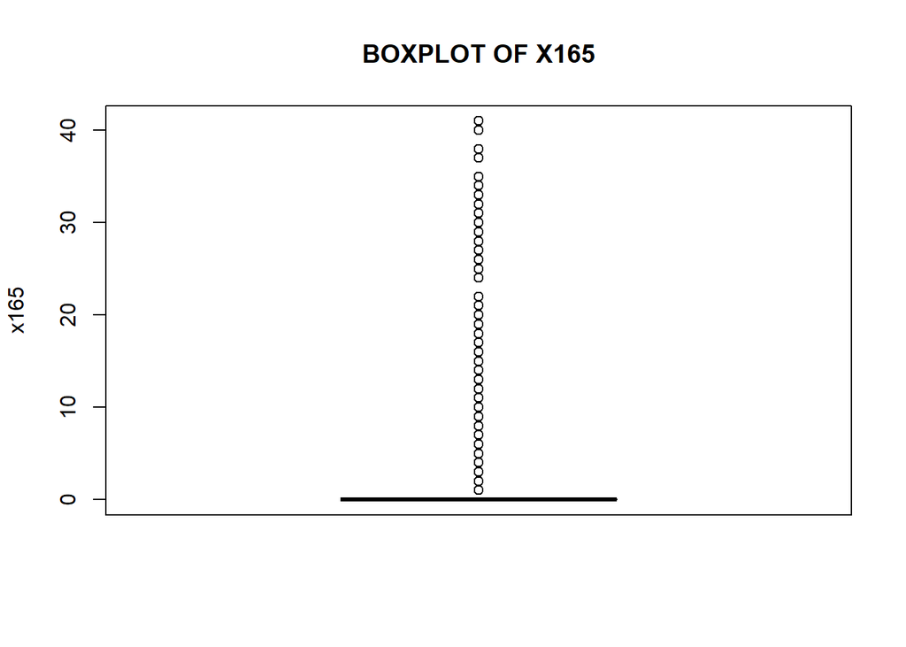

```r
##Boxplot
boxplot(data$x165,
       main = toupper("Boxplot of x165"),
       ylab = "x165",
       col = "blue")
```

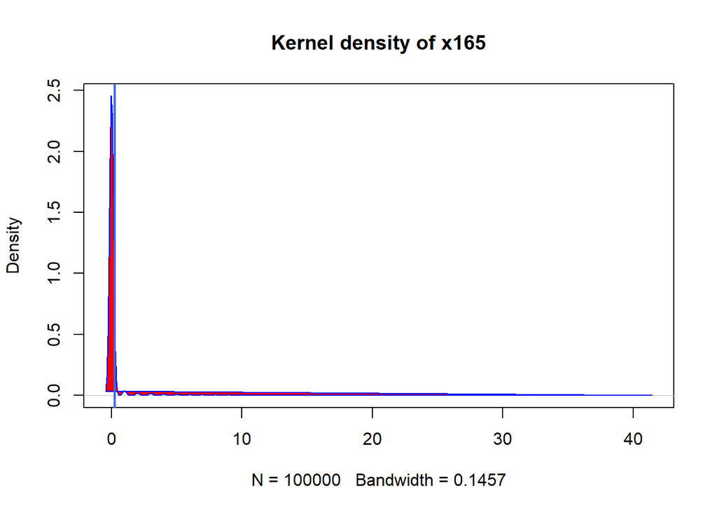

```r
##Density Plot
d <- density(data$x165, na.rm = TRUE)
plot(d, main = "Kernel density of x165")
polygon(d, col = "red", border = "blue")
abline(v =mean(data$x165, na.rm = TRUE),col = "royalblue",
lwd = 2)
```

## There is positive skewness in the data. There are no missing values. This variable have descrete values.

## Variable 166

```r
head(data$x166)
```

```
## [1] 0 0 0 0 0 0
```

```r
## Summary of the data
summary(data$x166)
```

```
##    Min. 1st Qu.  Median    Mean 3rd Qu.    Max.
##  0.0000  0.0000  0.0000  0.3222  0.0000 58.0000
```

##Here we found that mean and median are not pretty close and we can say that the distribution of the variable is not approximately normal

##Missing Values: ##There are no missing values

##Description of the data

```r
#install.packages("psych")

describe(data$x166)
```

```
##    vars     n mean   sd median trimmed mad min max range skew kurtosis
## X1    1 1e+05 0.32 2.03      0       0   0   0  58    58 9.64   118.84
##      se
## X1 0.01
```

## Here the kurtosis is very high positive hence there is large data in tail

```r
table(data$x166)
```

```
##
##     0     1     2     3     4     5     6     7     8     9    10    11
## 94571  1441   753   564   418   361   266   209   200   135   126   112
##    12    13    14    15    16    17    18    19    20    21    22    23
##    89    98    84    72    62    49    42    54    43    39    26    20
##    24    25    26    27    28    29    30    31    32    33    34    35
##    30    17    26    20     5     6    14     6     7    10     9     2
##    37    38    40    41    43    44    53    55    58
##     1     2     4     2     1     1     1     1     1
```

```r
str(data$x166)
```

```
##  int [1:100000] 0 0 0 0 0 0 0 0 0 3 ...
```

```r
class(data$x166)
```

```
## [1] "integer"
```

## here the all values in integer

```r
##Total number of values excluding NA
NROW(data[which(data$x166<=2),])
```

```
## [1] 96765
```

##i.e;., 96%

```r
NROW(data[which(data$x166<=5),])
```

```
## [1] 98108
```

##i.e;.,98%

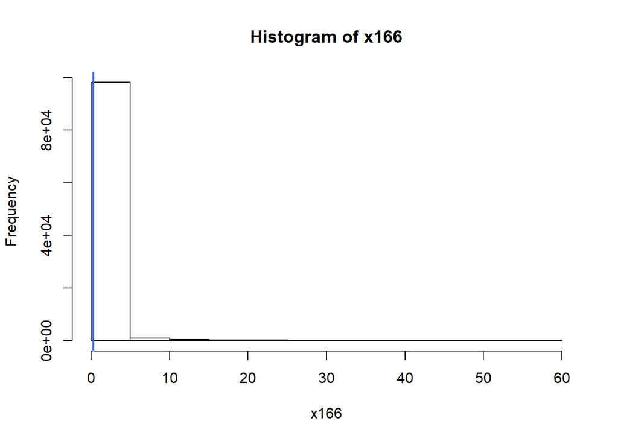

```r
##Now visualize the statistics
##Histogram

hist(data$x166,
    main = "Histogram of x166",
    xlab = "x166")
abline(v =mean(data$x166, na.rm = TRUE),col = "royalblue",
lwd = 2)
```

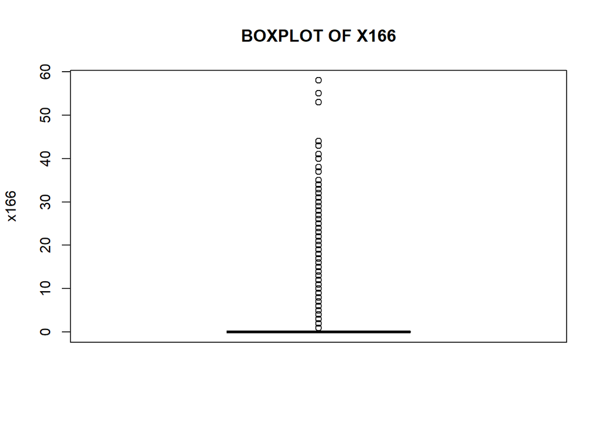

```r
##Boxplot
boxplot(data$x166,
       main = toupper("Boxplot of x166"),
       ylab = "x166",
       col = "blue")
```

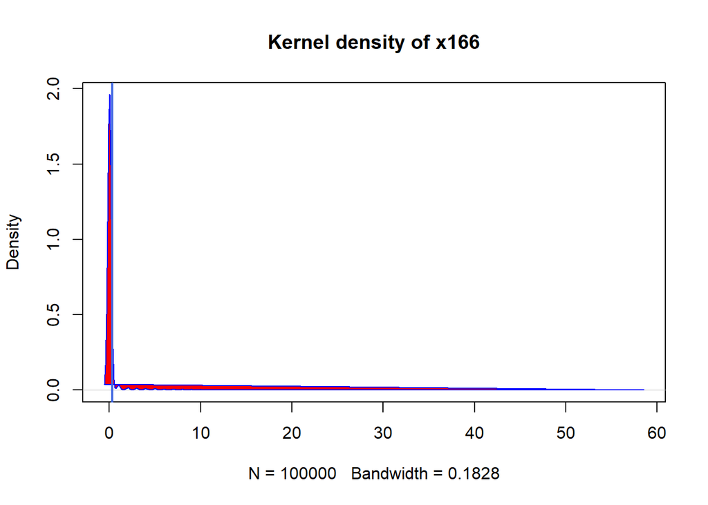

```r
##Density Plot
d <- density(data$x166, na.rm = TRUE)
plot(d, main = "Kernel density of x166")
polygon(d, col = "red", border = "blue")
abline(v =mean(data$x166, na.rm = TRUE),col = "royalblue",
lwd = 2)
```

## Obervation ## From the above graphs and stats i observed that 96% are below 2 and 98% are below 5

## There is positive skewness in the data. There are no missing values. This variable have descrete values.

## Variable 167

```r
head(data$x167)
```

```
## [1] 0 0 0 0 0 0
```

```r
## Summary of the data
summary(data$x167)
```

```
##    Min. 1st Qu.  Median    Mean 3rd Qu.    Max.
##  0.0000  0.0000  0.0000  0.3502  0.0000 62.0000
```

##Here we found that mean and median are not pretty close and we can say that the distribution of the variable is not approximately normal

##Missing Values: ##There are no missing values

##Description of the data

```r
#install.packages("psych")


describe(data$x167)
```

```
##    vars     n mean   sd median trimmed mad min max range  skew kurtosis
## X1    1 1e+05 0.35 2.27      0       0   0   0  62    62 10.38   139.26
##      se
## X1 0.01
```

## Here the kurtosis is very high positive hence there is large data in tail

```r
table(data$x167)
```

```
##
##     0     1     2     3     4     5     6     7     8     9    10    11
## 94476  1448   765   553   417   363   273   198   207   136   134   117
##    12    13    14    15    16    17    18    19    20    21    22    23
##    98    94    90    67    60    48    36    43    41    43    25    35
##    24    25    26    27    28    29    30    31    32    33    34    35
##    27    18    27    23    11    11     9    11    11     6     7    12
##    36    37    38    39    40    41    42    43    44    45    46    47
##    12     4     3     9     3     2     3     2     5     5     5     1
##    50    51    53    59    61    62
##     1     1     1     1     1     1
```

```r
str(data$x167)
```

```
##  int [1:100000] 0 0 0 0 0 0 0 0 0 3 ...
```

```r
class(data$x167)
```

```
## [1] "integer"
```

## here the all values in integer

```r
##Total number of values excluding NA
NROW(data[which(data$x167<=2),])
```

```
## [1] 96689
```

##i.e;., 96%

```r
NROW(data[which(data$x167<=5),])
```

```
## [1] 98022
```

##i.e;.,98%

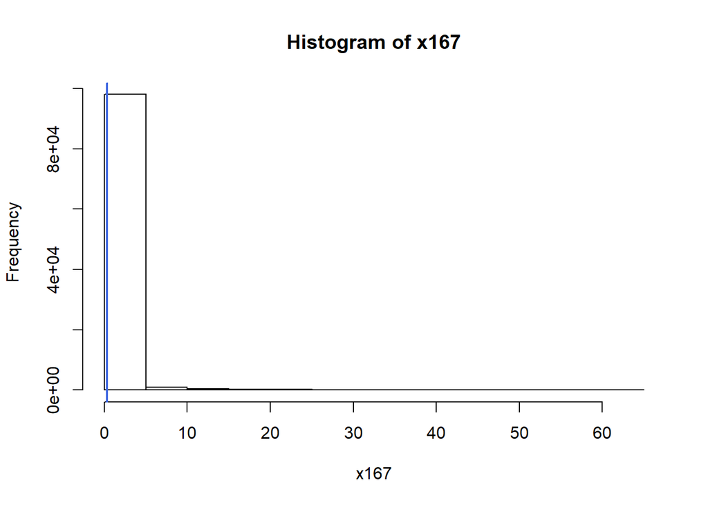

```r
##Now visualize the statistics
##Histogram

hist(data$x167,
    main = "Histogram of x167",
    xlab = "x167")
abline(v =mean(data$x167, na.rm = TRUE),col = "royalblue",
lwd = 2)
```

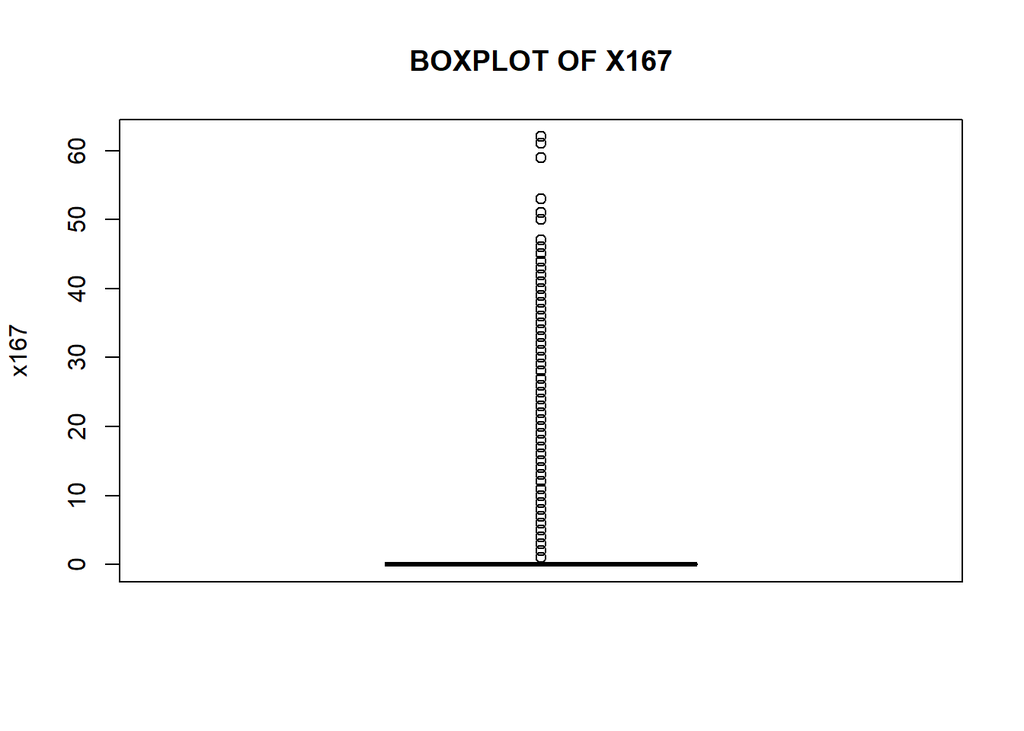

```r
##Boxplot
boxplot(data$x167,
       main = toupper("Boxplot of x167"),
       ylab = "x167",
       col = "blue")
```

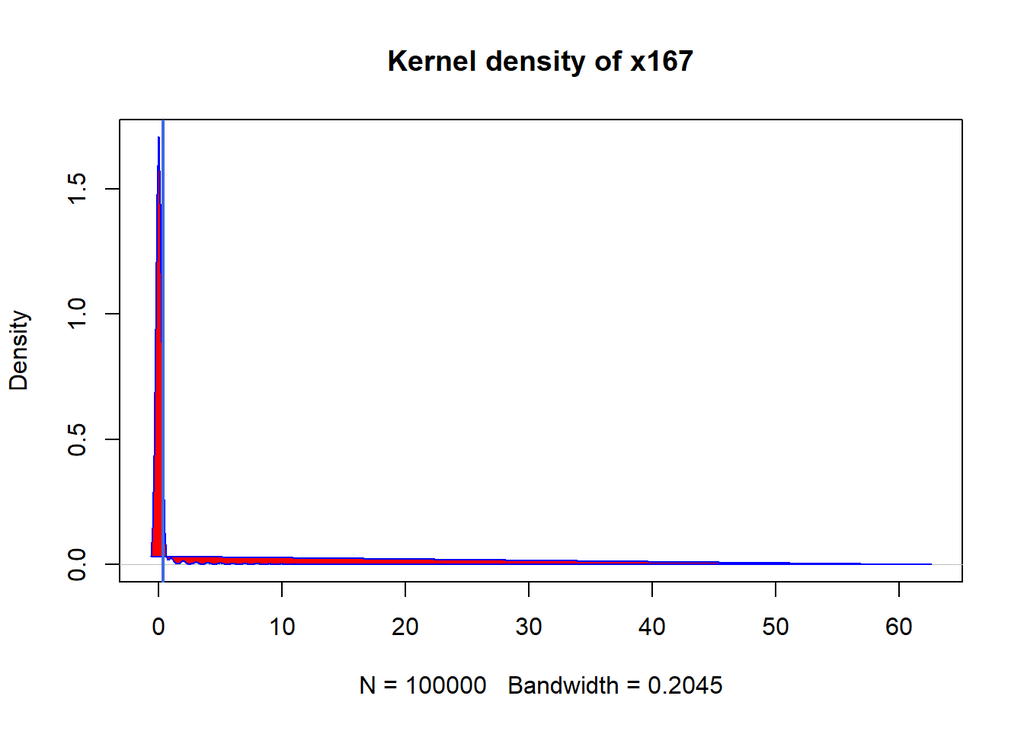

```r
##Density Plot
d <- density(data$x167, na.rm = TRUE)
plot(d, main = "Kernel density of x167")
polygon(d, col = "red", border = "blue")
abline(v =mean(data$x167, na.rm = TRUE),col = "royalblue",
lwd = 2)
```

## Obervation ## From the above graphs and stats i observed that 96% are below 2 and 98% are below 5

## There is positive skewness in the data. There are no missing values. This variable have descrete values.

## Variable 168

```r
head(data$x168)
```

```
## [1] 0 0 5 0 1 1
```

```r
## Summary of the data
summary(data$x168)
```

```
##    Min. 1st Qu.  Median    Mean 3rd Qu.    Max.
##  0.0000  0.0000  0.0000  0.7771  1.0000 32.0000
```

##Here we found that mean and median are not pretty close and we can say that the distribution of the variable is not approximately normal

##Missing Values: ##There are no missing values

##Description of the data

```r
#install.packages("psych")


describe(data$x168)
```

```
##    vars     n mean   sd median trimmed mad min max range skew kurtosis
## X1    1 1e+05 0.78 1.63      0    0.38   0   0  32    32 3.72    22.43
##      se
## X1 0.01
```

## Here the kurtosis is very high positive hence there is large data in tail

```r
table(data$x168)
```

```
##
##     0     1     2     3     4     5     6     7     8     9    10    11
## 67499 14803  7344  4109  2412  1454   874   515   318   223   147    82
##    12    13    14    15    16    17    18    19    20    21    22    23
##    62    50    33    19    15    12     4     6     3     8     1     1
##    25    26    27    32
##     2     2     1     1
```

```r
str(data$x168)
```

```
##  int [1:100000] 0 0 5 0 1 1 1 1 1 0 ...
```

```r
class(data$x168)
```

```
## [1] "integer"
```

## here the all values in integer

```r
##Total number of values excluding NA
NROW(data[which(data$x168<=2),])
```

```
## [1] 89646
```

```r
NROW(data[which(data$x168<=5),])
```

```
## [1] 97621
```

##i.e;.,98%

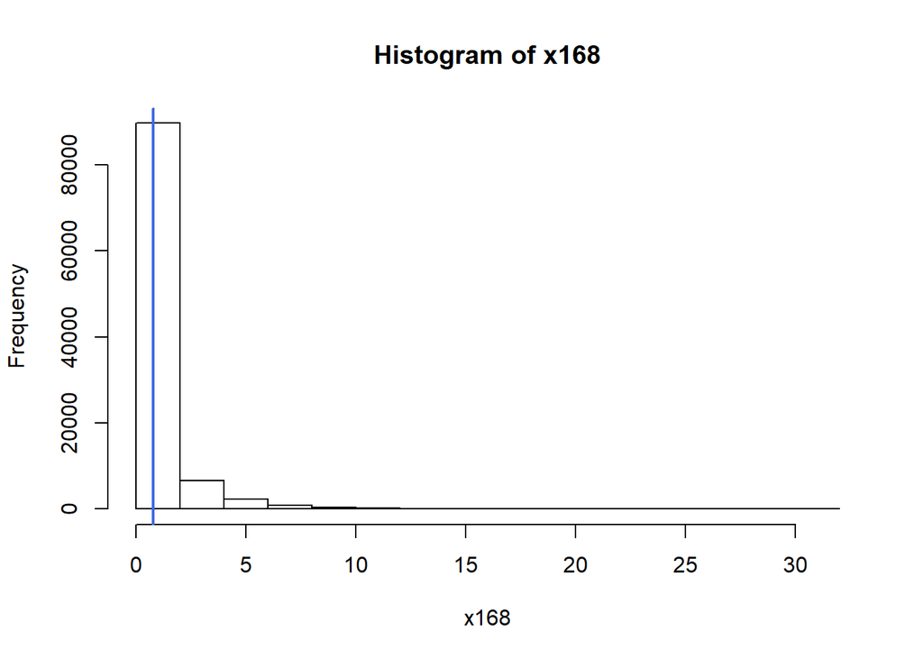

```r
##Now visualize the statistics
##Histogram

hist(data$x168,
    main = "Histogram of x168",
    xlab = "x168")
abline(v =mean(data$x168, na.rm = TRUE),col = "royalblue",
lwd = 2)
```

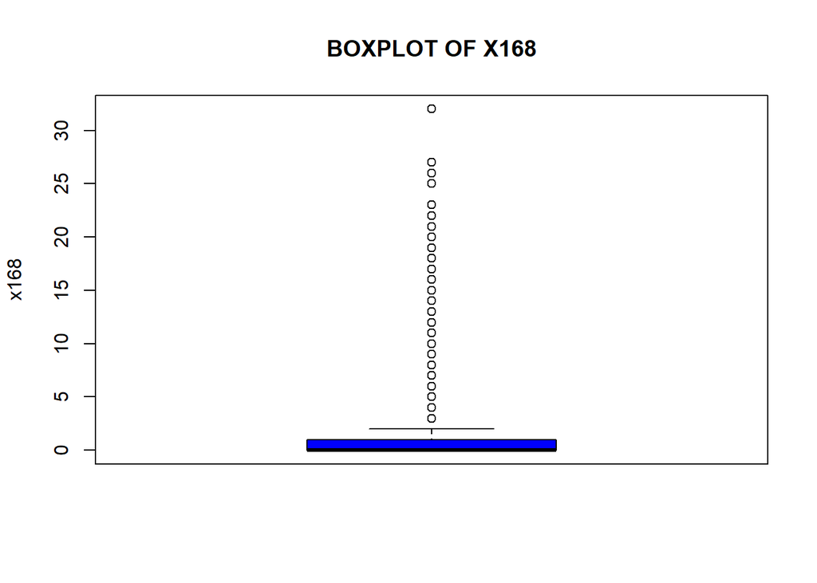

```r
##Boxplot
boxplot(data$x168,
       main = toupper("Boxplot of x168"),
       ylab = "x168",
       col = "blue")
```

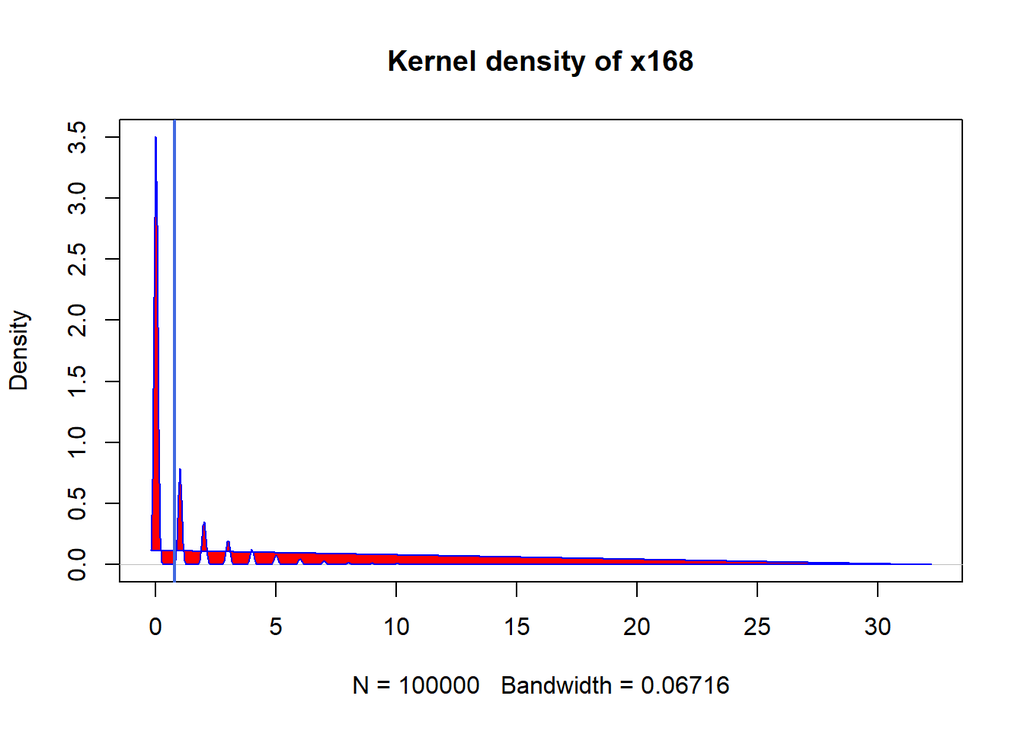

```r
##Density Plot
d <- density(data$x168, na.rm = TRUE)
plot(d, main = "Kernel density of x168")
polygon(d, col = "red", border = "blue")
abline(v =mean(data$x168, na.rm = TRUE),col = "royalblue",
lwd = 2)
```

## There is positive skewness in the data. There are no missing values. This variable have descrete values.

## Variable 169

```r
head(data$x169)
```

```
## [1] 0 0 0 0 0 0
```

```r
## Summary of the data
summary(data$x169)
```

```
##    Min. 1st Qu.  Median    Mean 3rd Qu.    Max.
##  0.0000  0.0000  0.0000  0.1102  0.0000 24.0000
```

##Here we found that mean and median are not pretty close and we can say that the distribution of the variable is not approximately normal

##Missing Values: ##There are no missing values

##Description of the data

```r
#install.packages("psych")


describe(data$x169)
```

```
##    vars     n mean   sd median trimmed mad min max range  skew kurtosis se
## X1    1 1e+05 0.11 0.52      0       0   0   0  24    24 10.56   221.33  0
```

## Here the kurtosis is very high positive hence there is large data in tail

```r
table(data$x169)
```

```
##
##     0     1     2     3     4     5     6     7     8     9    10    11
## 92842  5120  1226   421   170    89    53    27    19    10     5     2
##    12    13    14    15    19    23    24
##     6     2     1     3     2     1     1
```

```r
str(data$x169)
```

```
##  int [1:100000] 0 0 0 0 0 0 1 0 0 0 ...
```

```r
class(data$x169)
```

```
## [1] "integer"
```

## here the all values in integer

```r
##Total number of values excluding NA
NROW(data[which(data$x169<=2),])
```

```
## [1] 99188
```

```r
NROW(data[which(data$x169<=5),])
```

```
## [1] 99868
```

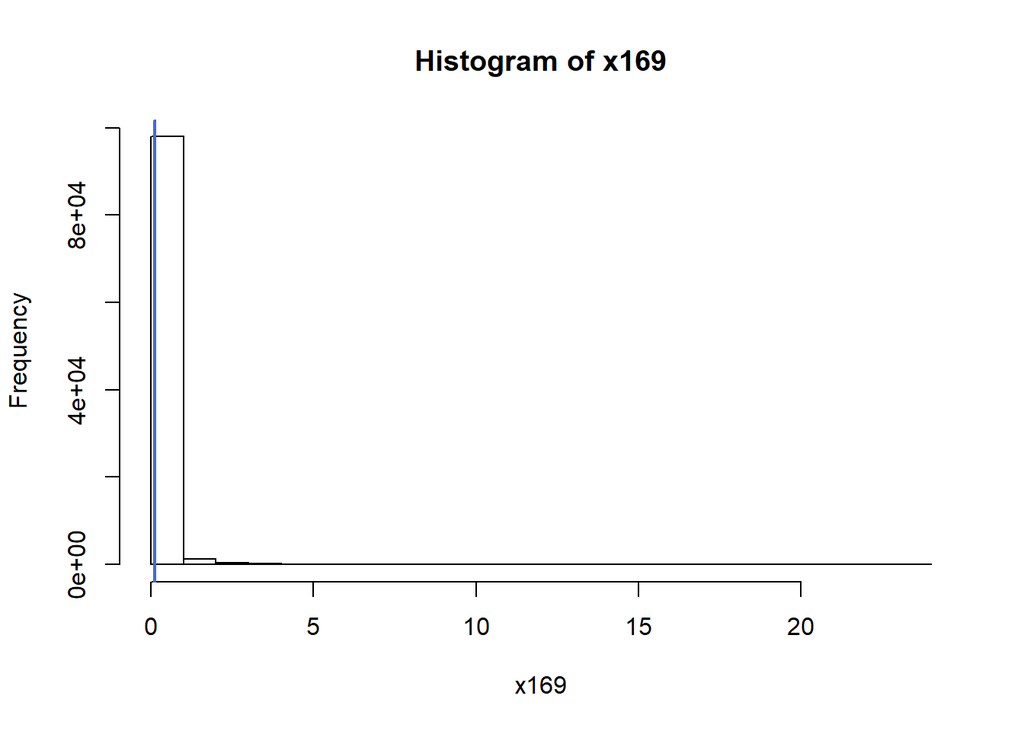

```r
##Now visualize the statistics
##Histogram

hist(data$x169,
    main = "Histogram of x169",
    xlab = "x169")
abline(v =mean(data$x169, na.rm = TRUE),col = "royalblue",
lwd = 2)
```

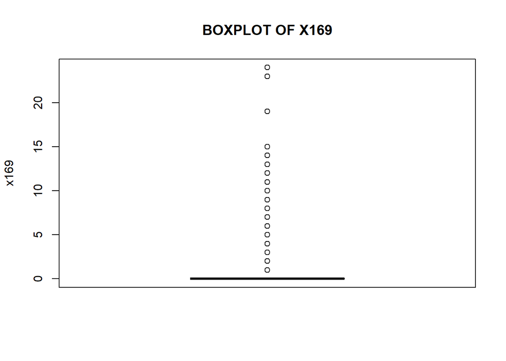

```r
##Boxplot
boxplot(data$x169,
       main = toupper("Boxplot of x169"),
       ylab = "x169",
       col = "blue")
```

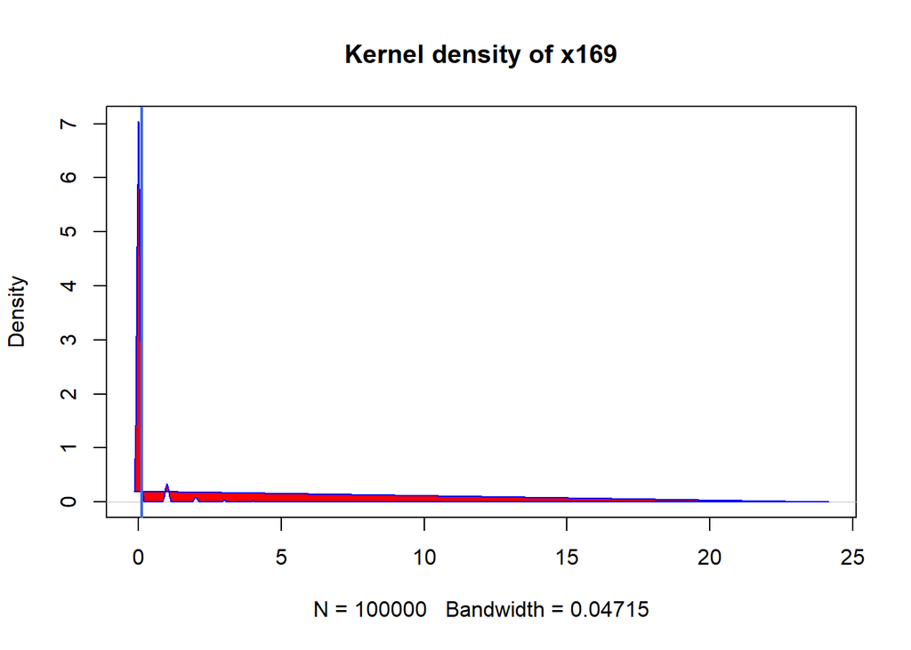

```r
##Density Plot
d <- density(data$x169, na.rm = TRUE)
plot(d, main = "Kernel density of x169")
polygon(d, col = "red", border = "blue")
abline(v =mean(data$x169, na.rm = TRUE),col = "royalblue",
lwd = 2)
```

## There is positive skewness in the data. There are no missing values. This variable have descrete values.

## Variable 170

```r
head(data$x170)
```

```
## [1] 0 0 0 0 1 0
```

```r
## Summary of the data
summary(data$x170)
```

```
##    Min. 1st Qu.  Median    Mean 3rd Qu.    Max.
##  0.0000  0.0000  0.0000  0.2074  0.0000 28.0000
```

##Here we found that mean and median are not pretty close and we can say that the distribution of the variable is not approximately normal

##Missing Values: ##There are no missing values

##Description of the data

```r
#install.packages("psych")

describe(data$x170)
```

```
##    vars     n mean  sd median trimmed mad min max range skew kurtosis se
## X1    1 1e+05 0.21 0.8      0    0.02   0   0  28    28 8.37   121.84  0
```

## Here the kurtosis is very high positive hence there is large data in tail

```r
table(data$x170)
```

```
##
##     0     1     2     3     4     5     6     7     8     9    10    11
## 88344  7441  2325   863   418   211   136    85    53    35    20    15
##    12    13    14    15    16    17    18    19    20    21    25    28
##    10    15     4     6     5     5     2     1     1     3     1     1
```

```r
str(data$x170)
```

```
##  int [1:100000] 0 0 0 0 1 0 1 0 0 0 ...
```

```r
class(data$x170)
```

```
## [1] "integer"
```

## here the all values in integer

```r
##Total number of values excluding NA
NROW(data[which(data$x170<=2),])
```

```
## [1] 98110
```

##i.e;., 98%

```r
NROW(data[which(data$x170<=5),])
```

```
## [1] 99602
```

##i.e;.,99%

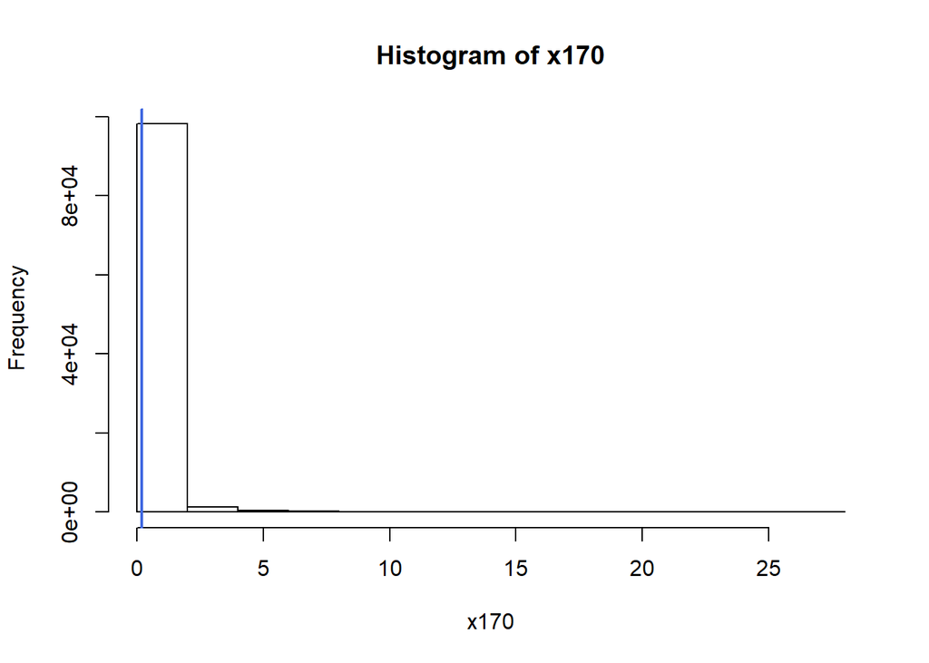

```r
##Now visualize the statistics
##Histogram

hist(data$x170,
    main = "Histogram of x170",
    xlab = "x170")
abline(v =mean(data$x170, na.rm = TRUE),col = "royalblue",
lwd = 2)
```

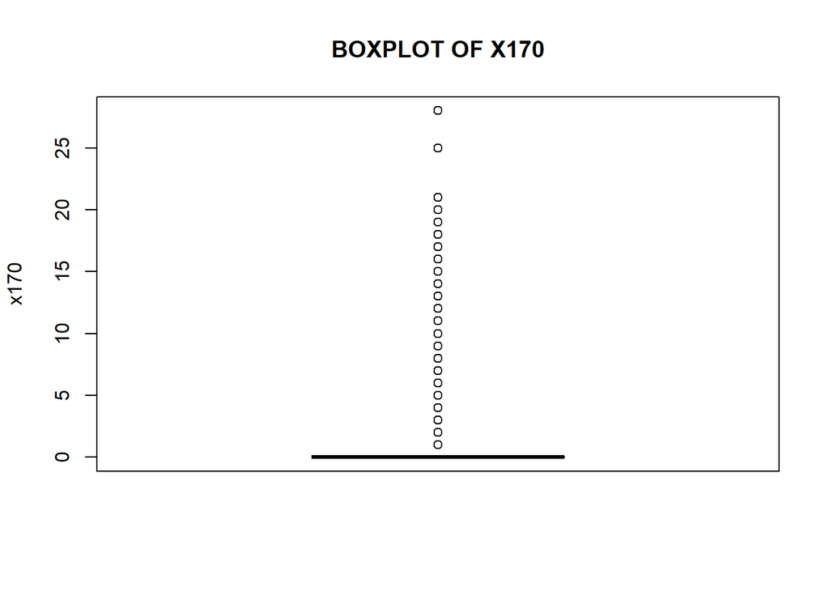

```r
##Boxplot
boxplot(data$x170,
       main = toupper("Boxplot of x170"),
       ylab = "x170",
       col = "blue")
```

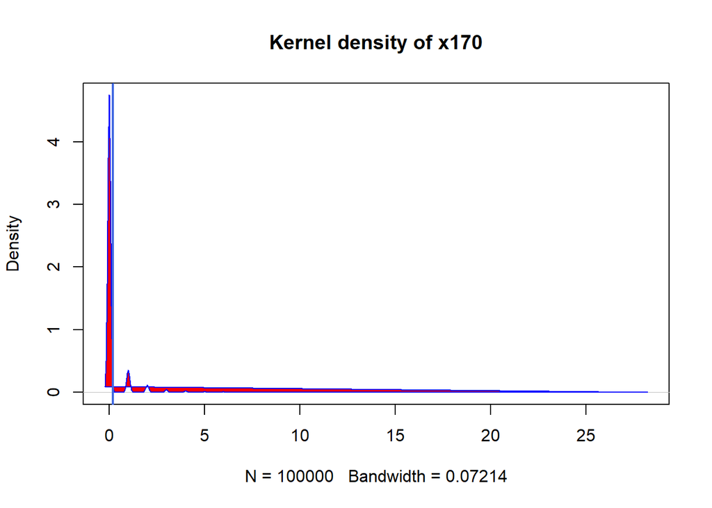

```r
##Density Plot
d <- density(data$x170, na.rm = TRUE)
plot(d, main = "Kernel density of x170")
polygon(d, col = "red", border = "blue")
abline(v =mean(data$x170, na.rm = TRUE),col = "royalblue",
lwd = 2)
```

## Obervation ## From the above graphs and stats i observed that 98% are below 2 and 99% are below 5

## There is positive skewness in the data. There are no missing values. This variable have descrete values.

## Variable 171

```r
head(data$x171)
```

```
## [1] 0 0 0 0 1 0
```

```r
## Summary of the data
summary(data$x171)
```

```
##    Min. 1st Qu.  Median    Mean 3rd Qu.    Max.
##  0.0000  0.0000  0.0000  0.3552  0.0000 30.0000
```

##Here we found that mean and median are not pretty close and we can say that the distribution of the variable is not approximately normal

##Missing Values: ##There are no missing values

##Description of the data

```r
#install.packages("psych")


describe(data$x171)
```

```
##    vars     n mean   sd median trimmed mad min max range skew kurtosis se
## X1    1 1e+05 0.36 1.09      0     0.1   0   0  30    30 6.27    66.85  0
```

## Here the kurtosis is very high positive hence there is large data in tail

```r
table(data$x171)
```

```
##
##     0     1     2     3     4     5     6     7     8     9    10    11
## 82129 10286  3786  1627   824   506   287   179   124    72    47    40
##    12    13    14    15    16    17    18    19    20    21    23    25
##    23    16     9    11     8     7     3     3     1     7     1     1
##    26    30
##     2     1
```

```r
str(data$x171)
```

```
##  int [1:100000] 0 0 0 0 1 0 1 0 0 0 ...
```

```r
class(data$x171)
```

```
## [1] "integer"
```

## here the all values in integer

```r
##Total number of values excluding NA
NROW(data[which(data$x171<=2),])
```

```
## [1] 96201
```

##i.e;., 96%

```r
NROW(data[which(data$x171<=5),])
```

```
## [1] 99158
```

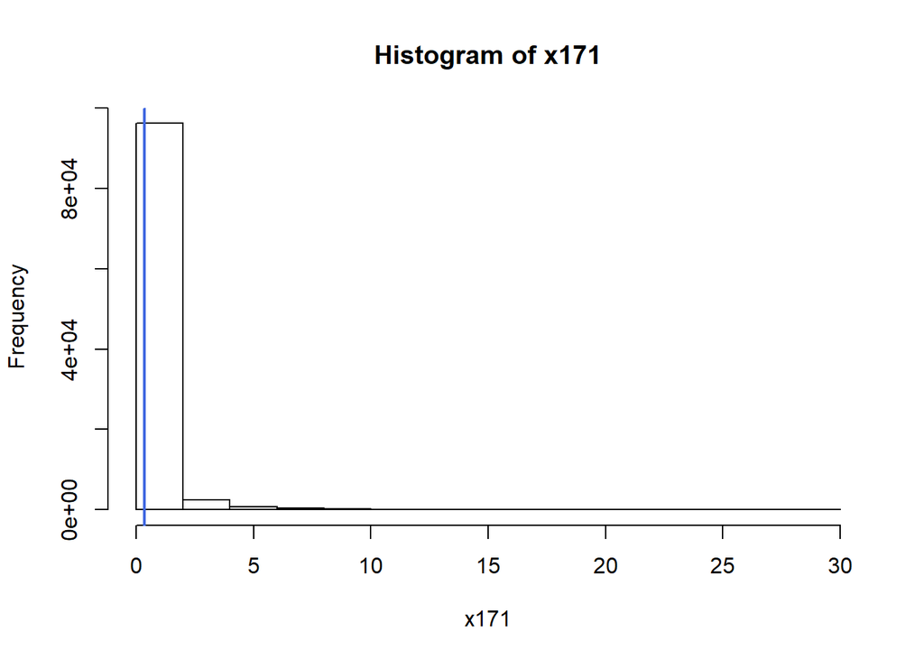

```r
##Now visualize the statistics
##Histogram

hist(data$x171,
    main = "Histogram of x171",
    xlab = "x171")
abline(v =mean(data$x171, na.rm = TRUE),col = "royalblue",
lwd = 2)
```

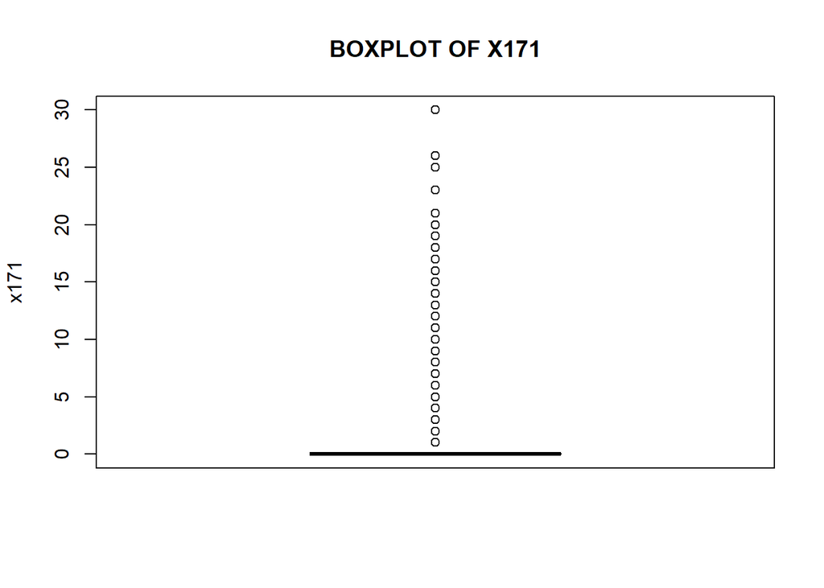

```r
##Boxplot
boxplot(data$x171,
       main = toupper("Boxplot of x171"),
       ylab = "x171",
       col = "blue")
```

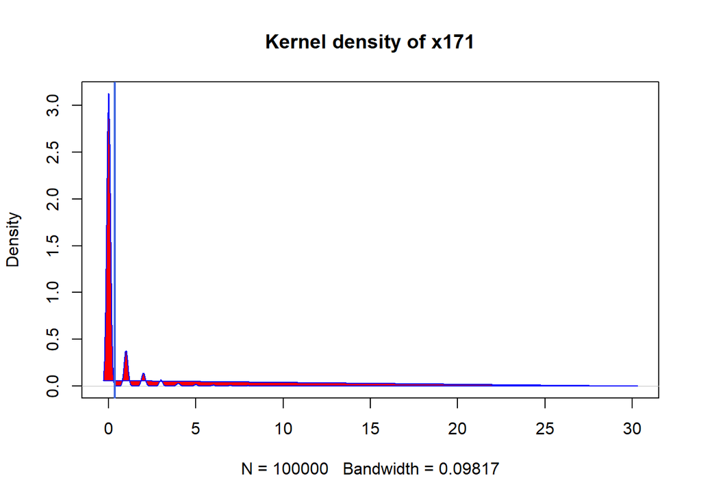

```r
##Density Plot
d <- density(data$x171, na.rm = TRUE)
plot(d, main = "Kernel density of x171")
polygon(d, col = "red", border = "blue")
abline(v =mean(data$x171, na.rm = TRUE),col = "royalblue",
lwd = 2)
```

## There is positive skewness in the data. There are no missing values. This variable have descrete values.

## Variable 172

```r
head(data$x172)
```

```
## [1] 0 0 0 0 1 0
```

```r
## Summary of the data
summary(data$x172)
```

```
##    Min. 1st Qu.  Median    Mean 3rd Qu.    Max.
##  0.0000  0.0000  0.0000  0.4759  0.0000 30.0000
```

##Here we found that mean and median are not pretty close and we can say that the distribution of the variable is not approximately normal

##Missing Values: ##There are no missing values

##Description of the data

```r
#install.packages("psych")


describe(data$x172)
```

```
##    vars     n mean   sd median trimmed mad min max range skew kurtosis se
## X1    1 1e+05 0.48 1.26      0    0.16   0   0  30    30 5.16    44.58  0
```

## Here the kurtosis is very high positive hence there is large data in tail

```r
table(data$x172)
```

```
##
##     0     1     2     3     4     5     6     7     8     9    10    11
## 77393 12104  4957  2332  1271   732   437   258   170   106    68    45
##    12    13    14    15    16    17    18    19    20    21    23    25
##    33    25    14    15     8     8     5     3     1    10     1     1
##    26    30
##     2     1
```

```r
str(data$x172)
```

```
##  int [1:100000] 0 0 0 0 1 0 1 0 0 0 ...
```

```r
class(data$x172)
```

```
## [1] "integer"
```

## here the all values in integer

```r
##Total number of values excluding NA
NROW(data[which(data$x172<=2),])
```

```
## [1] 94454
```

```r
NROW(data[which(data$x172<=5),])
```

```
## [1] 98789
```

##i.e;.,98%

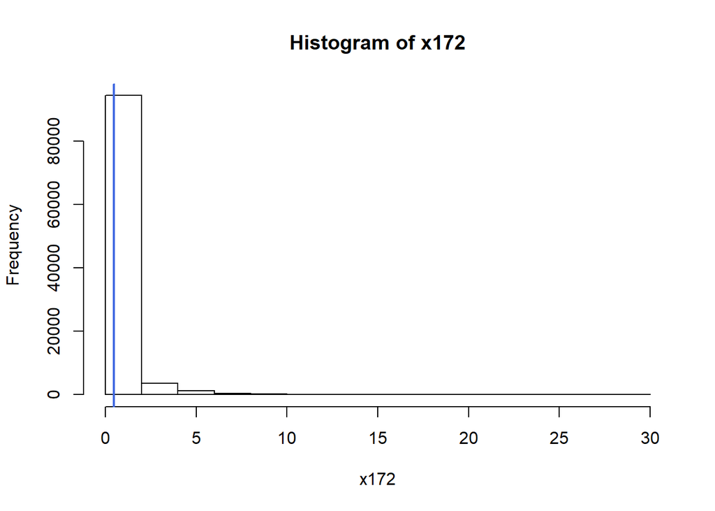

```r
##Now visualize the statistics
##Histogram

hist(data$x172,
    main = "Histogram of x172",
    xlab = "x172")
abline(v =mean(data$x172, na.rm = TRUE),col = "royalblue",
lwd = 2)
```

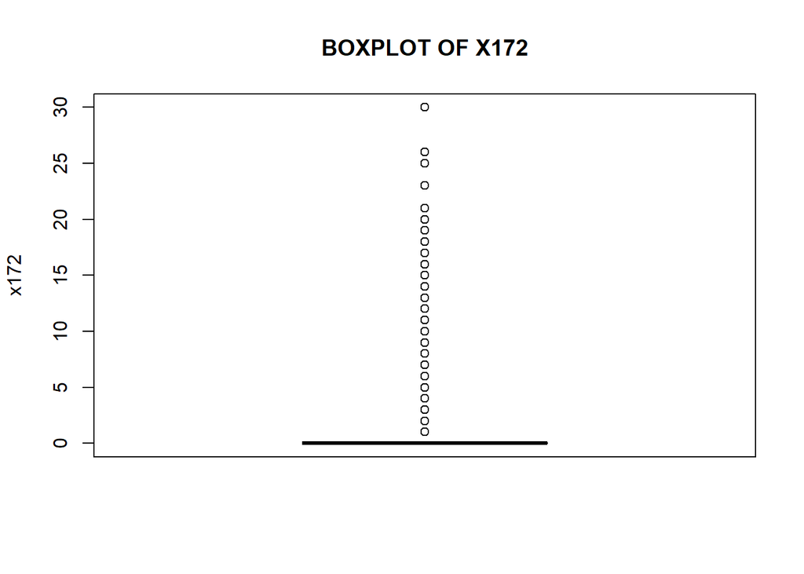

```r
##Boxplot
boxplot(data$x172,
       main = toupper("Boxplot of x172"),
       ylab = "x172",
       col = "blue")
```

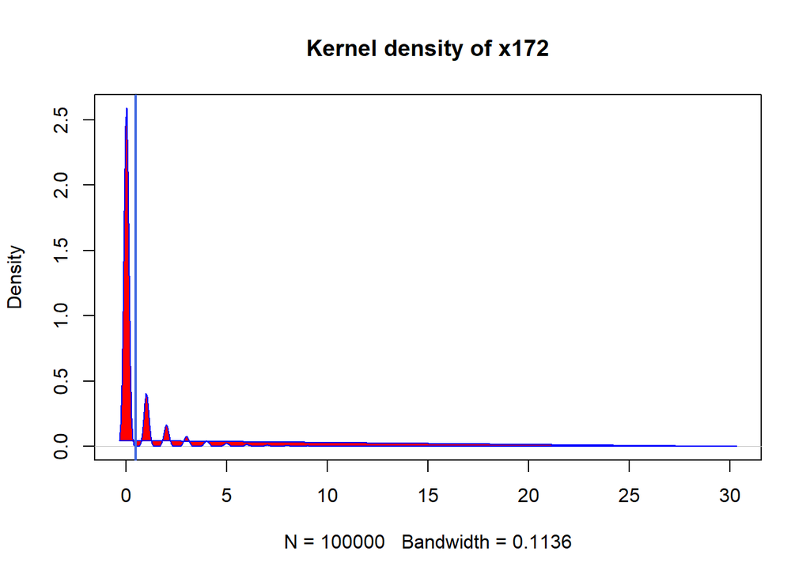

```r
##Density Plot
d <- density(data$x172, na.rm = TRUE)
plot(d, main = "Kernel density of x172")
polygon(d, col = "red", border = "blue")
abline(v =mean(data$x172, na.rm = TRUE),col = "royalblue",
lwd = 2)
```

## There is positive skewness in the data. There are no missing values. This variable have descrete values.

## Variable 173

```r
head(data$x173)
```

```
## [1] 0 0 5 0 1 1
```

```r
## Summary of the data
summary(data$x173)
```

```
##    Min. 1st Qu.  Median    Mean 3rd Qu.    Max.
##  0.0000  0.0000  0.0000  0.6575  1.0000 30.0000
```

##Here we found that mean and median are not pretty close and we can say that the distribution of the variable is not approximately normal

##Missing Values: ##There are no missing values

##Description of the data

```r
#install.packages("psych")


describe(data$x173)
```

```
##    vars     n mean   sd median trimmed mad min max range skew kurtosis se
## X1    1 1e+05 0.66 1.49      0     0.3   0   0  30    30 4.11    27.24  0
```

## Here the kurtosis is very high positive hence there is large data in tail

```r
table(data$x173)
```

```
##
##     0     1     2     3     4     5     6     7     8     9    10    11
## 71261 13843  6472  3446  1946  1153   690   385   260   169   123    77
##    12    13    14    15    16    17    18    19    20    21    22    23
##    51    40    23    15    10     9     4     5     3     9     1     1
##    25    26    30
##     1     2     1
```

```r
str(data$x173)
```

```
##  int [1:100000] 0 0 5 0 1 1 1 0 1 0 ...
```

```r
class(data$x173)
```

```
## [1] "integer"
```

## here the all values in integer

```r
##Total number of values excluding NA
NROW(data[which(data$x173<=2),])
```

```
## [1] 91576
```

##i.e;., 91%

```r
NROW(data[which(data$x173<=5),])
```

```
## [1] 98121
```

##i.e;.,98%

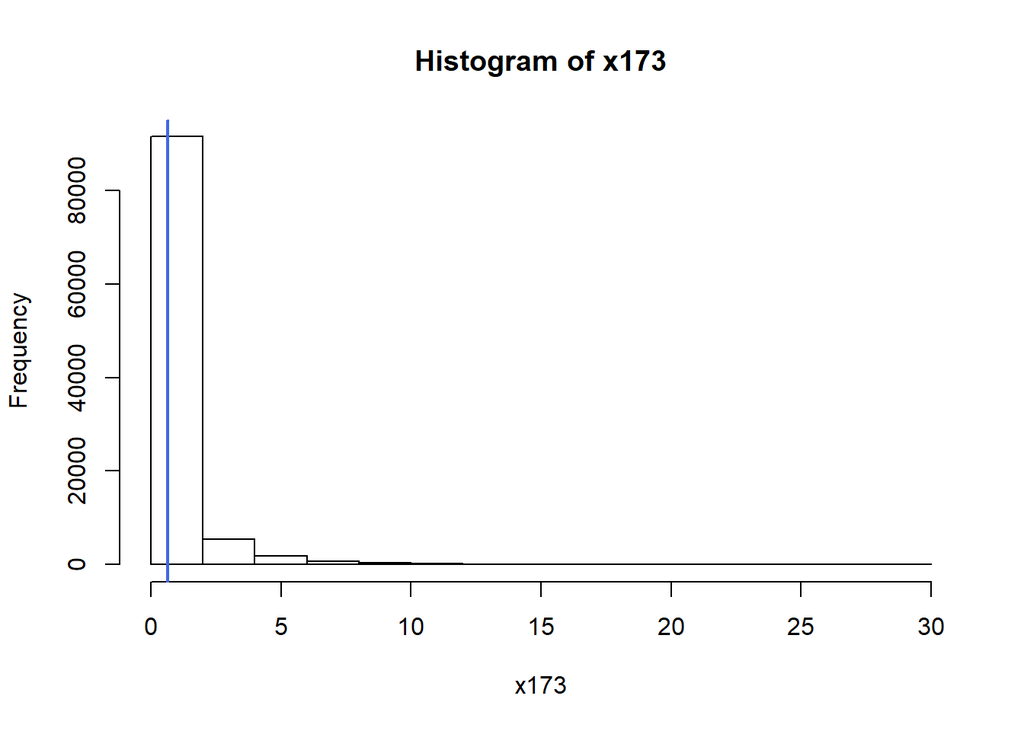

```r
##Now visualize the statistics
##Histogram

hist(data$x173,
    main = "Histogram of x173",
    xlab = "x173")
abline(v =mean(data$x173, na.rm = TRUE),col = "royalblue",
lwd = 2)
```

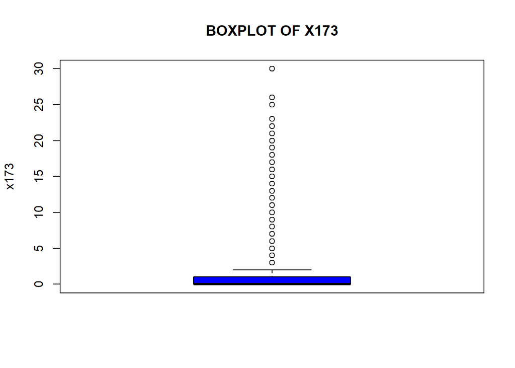

```r
##Boxplot
boxplot(data$x173,
       main = toupper("Boxplot of x173"),
       ylab = "x173",
       col = "blue")
```

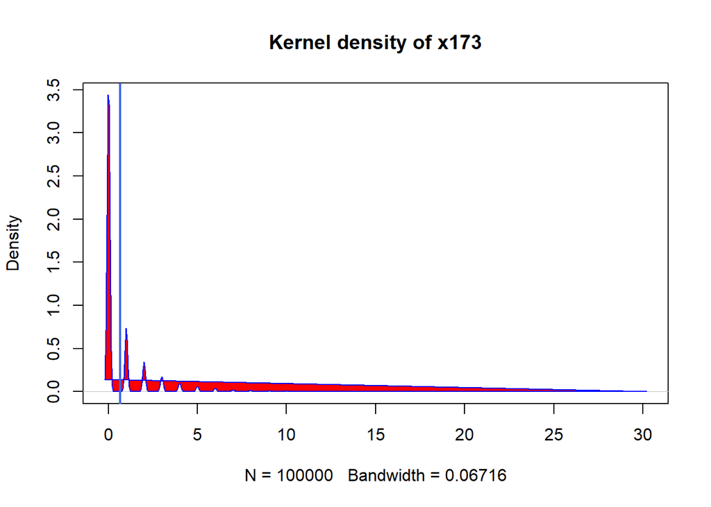

```r
##Density Plot
d <- density(data$x173, na.rm = TRUE)
plot(d, main = "Kernel density of x173")
polygon(d, col = "red", border = "blue")
abline(v =mean(data$x173, na.rm = TRUE),col = "royalblue",
lwd = 2)
```

## Obervation ## From the above graphs and stats i observed that 91% are below 2 and 98% are below 5

## There is positive skewness in the data. There are no missing values. This variable have descrete values.

## Variable 174

```r
head(data$x174)
```

```
## [1] 0 0 3 0 1 0
```

```r
## Summary of the data
summary(data$x174)
```

```
##    Min. 1st Qu.  Median    Mean 3rd Qu.    Max.
##  0.0000  0.0000  0.0000  0.2995  0.0000 18.0000
```

##Here we found that mean and median are not pretty close and we can say that the distribution of the variable is not approximately normal

##Missing Values: ##There are no missing values

##Description of the data

```r
#install.packages("psych")


describe(data$x174)
```

```
##    vars     n mean   sd median trimmed mad min max range skew kurtosis se
## X1    1 1e+05  0.3 0.85      0    0.09   0   0  18    18 4.74    35.32  0
```

## Here the kurtosis is very high positive hence there is large data in tail

```r
table(data$x174)
```

```
##
##     0     1     2     3     4     5     6     7     8     9    10    11
## 82819 10490  3722  1516   689   375   172   101    52    25    16    11
##    12    13    14    15    16    17    18
##     2     2     1     2     2     2     1
```

```r
str(data$x174)
```

```
##  int [1:100000] 0 0 3 0 1 0 0 0 0 0 ...
```

```r
class(data$x174)
```

```
## [1] "integer"
```

## here the all values in integer

```r
##Total number of values excluding NA
NROW(data[which(data$x174<=2),])
```

```
## [1] 97031
```

##i.e;., 97%

```r
NROW(data[which(data$x174<=5),])
```

```
## [1] 99611
```

##i.e;.,99%

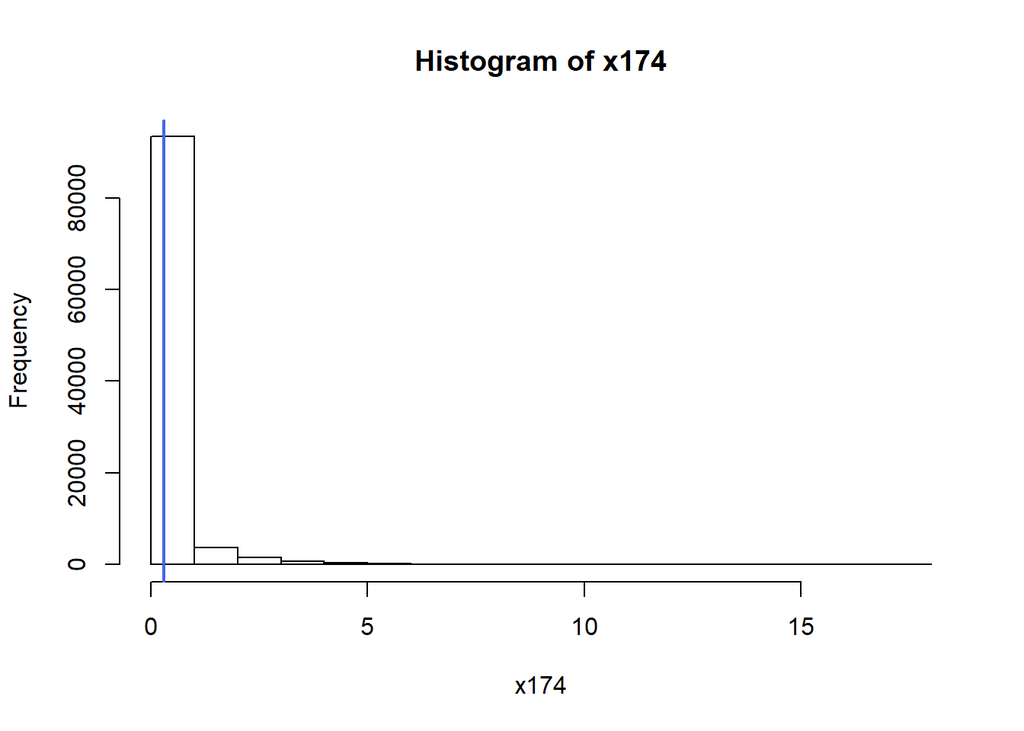

```r
##Now visualize the statistics
##Histogram

hist(data$x174,
    main = "Histogram of x174",
    xlab = "x174")
abline(v =mean(data$x174, na.rm = TRUE),col = "royalblue",
lwd = 2)
```

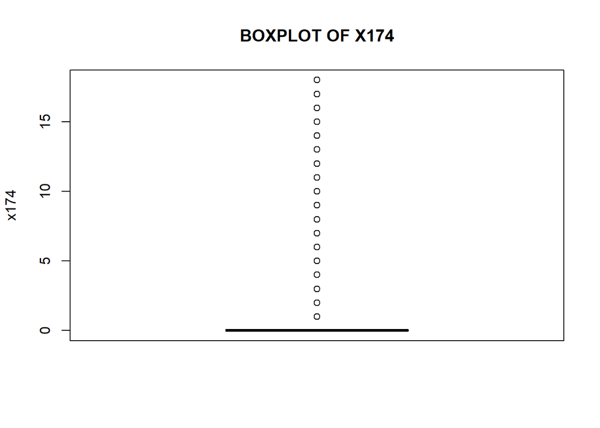

```r
##Boxplot
boxplot(data$x174,
       main = toupper("Boxplot of x174"),
       ylab = "x174",
       col = "blue")
```

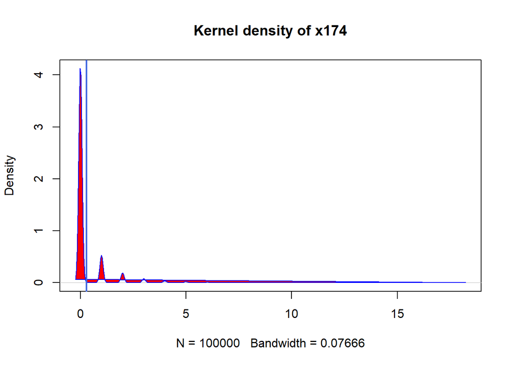

```r
##Density Plot
d <- density(data$x174, na.rm = TRUE)
plot(d, main = "Kernel density of x174")
polygon(d, col = "red", border = "blue")
abline(v =mean(data$x174, na.rm = TRUE),col = "royalblue",
lwd = 2)
```

## Obervation ## From the above graphs and stats i observed that 97% are below 2 and 99% are below 5

## There is positive skewness in the data. There are no missing values. This variable have descrete values.

## Variable 175

```r
head(data$x175)
```

```
## [1] 0 0 0 0 0 0
```

```r
## Summary of the data

summary(data$x175)
```

```
##    Min. 1st Qu.  Median    Mean 3rd Qu.    Max.
##  0.0000  0.0000  0.0000  0.0422  0.0000 13.0000
```

##Here we found that mean and median are not pretty close and we can say that the distribution of the variable is not approximately normal

##Missing Values: ##There are no missing values

##Description of the data

```r
#install.packages("psych")


describe(data$x175)
```

```
##    vars     n mean   sd median trimmed mad min max range skew kurtosis se
## X1    1 1e+05 0.04 0.29      0       0   0   0  13    13 11.3   208.58  0
```

## Here the kurtosis is very high positive hence there is large data in tail

```r
table(data$x175)
```

```
##
##     0     1     2     3     4     5     6     7     8     9    10    13
## 97009  2224   509   156    56    21    13     3     5     1     2     1
```

```r
str(data$x175)
```

```
##  int [1:100000] 0 0 0 0 0 0 0 0 0 0 ...
```

```r
class(data$x175)
```

```
## [1] "integer"
```

## here the all values in integer

```r
##Total number of values excluding NA
NROW(data[which(data$x175<=2),])
```

```
## [1] 99742
```

##i.e;., 99%

```r
NROW(data[which(data$x175<=5),])
```

```
## [1] 99975
```

##i.e;.,99%

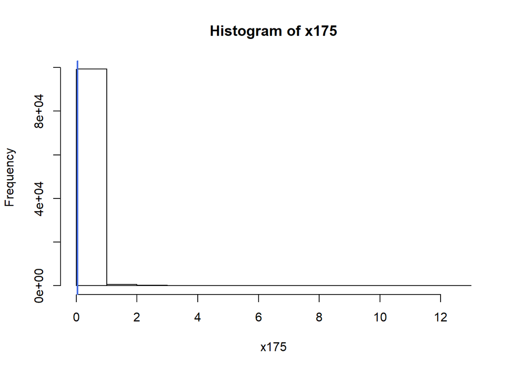

```r
##Now visualize the statistics
##Histogram

hist(data$x175,
    main = "Histogram of x175",
    xlab = "x175")
abline(v =mean(data$x175, na.rm = TRUE),col = "royalblue",
lwd = 2)
```

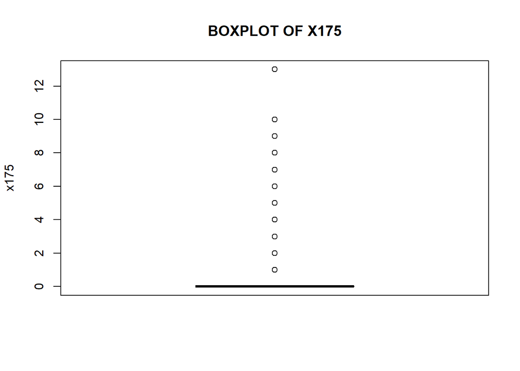

```r
##Boxplot
boxplot(data$x175,
       main = toupper("Boxplot of x175"),
       ylab = "x175",
       col = "blue")
```

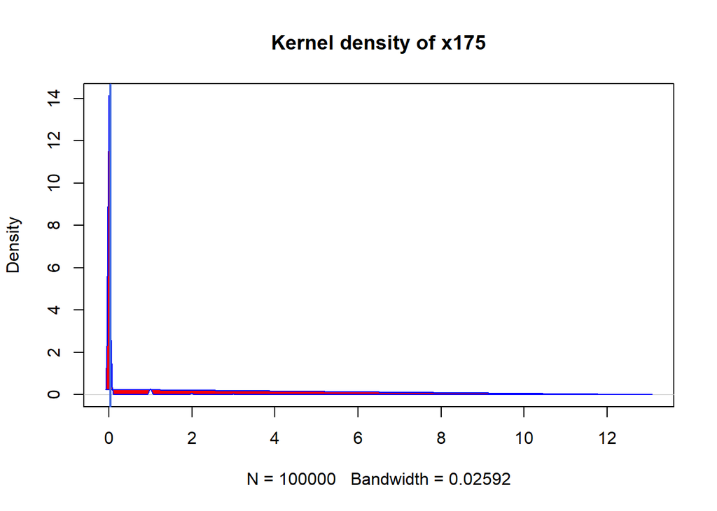

```r
##Density Plot
d <- density(data$x175, na.rm = TRUE)
plot(d, main = "Kernel density of x175")
polygon(d, col = "red", border = "blue")
abline(v =mean(data$x175, na.rm = TRUE),col = "royalblue",
lwd = 2)
```

## Obervation ## From the above graphs and stats i observed that 99% are below 2 and 99% are below 5

## There is positive skewness in the data. There are no missing values. This variable have descrete values.

## Variable 176

```r
head(data$x176)
```

```
## [1] 0 0 0 0 1 0
```

```r
## Summary of the data
summary(data$x176)
```

```
##     Min.  1st Qu.   Median     Mean  3rd Qu.     Max.
##  0.00000  0.00000  0.00000  0.08774  0.00000 13.00000
```

##Here we found that mean and median are not pretty close and we can say that the distribution of the variable is not approximately normal

##Missing Values: ##There are no missing values

##Description of the data

```r
#install.packages("psych")


describe(data$x176)
```

```
##    vars     n mean   sd median trimmed mad min max range skew kurtosis se
## X1    1 1e+05 0.09 0.45      0       0   0   0  13    13 8.58   110.34  0
```

## Here the kurtosis is very high positive hence there is large data in tail

```r
table(data$x176)
```

```
##
##     0     1     2     3     4     5     6     7     8     9    10    11
## 94467  3740  1068   393   153    87    43    16    15     8     4     3
##    12    13
##     2     1
```

```r
str(data$x176)
```

```
##  int [1:100000] 0 0 0 0 1 0 0 0 0 0 ...
```

```r
class(data$x176)
```

```
## [1] "integer"
```

## here the all values in integer

```r
##Total number of values excluding NA
NROW(data[which(data$x176<=2),])
```

```
## [1] 99275
```

##i.e;., 99%

```r
NROW(data[which(data$x176<=5),])
```

```
## [1] 99908
```

##i.e;.,99%

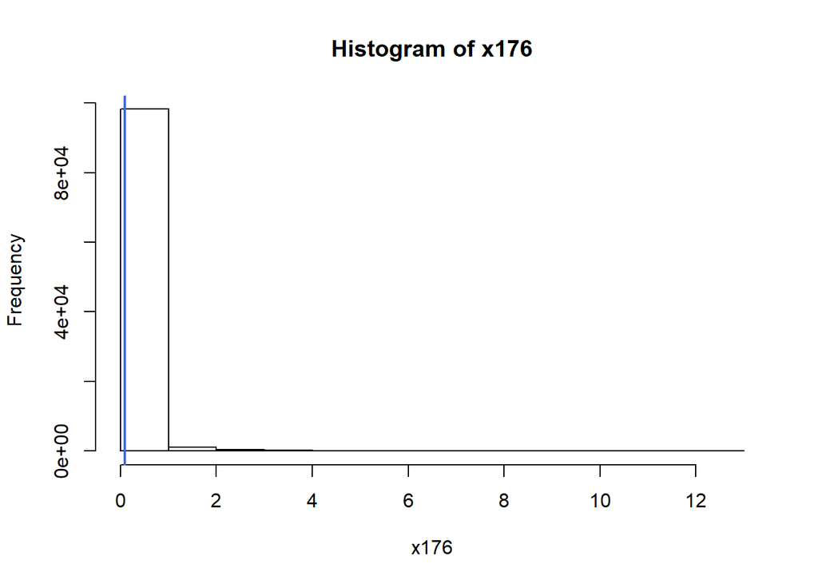

```r
##Now visualize the statistics
##Histogram

hist(data$x176,
    main = "Histogram of x176",
    xlab = "x176")
abline(v =mean(data$x176, na.rm = TRUE),col = "royalblue",
lwd = 2)
```

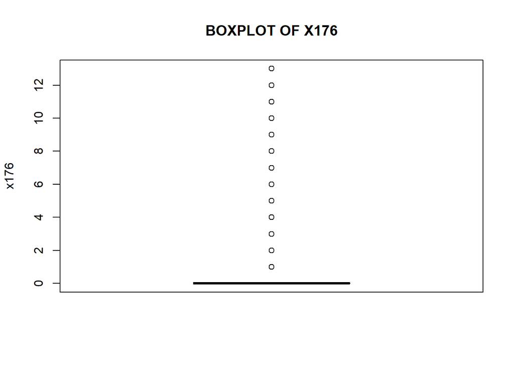

```r
##Boxplot
boxplot(data$x176,
       main = toupper("Boxplot of x176"),
       ylab = "x176",
       col = "blue")
```

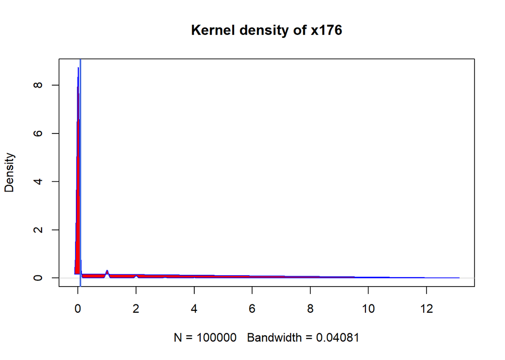

```r
##Density Plot
d <- density(data$x176, na.rm = TRUE)
plot(d, main = "Kernel density of x176")
polygon(d, col = "red", border = "blue")
abline(v =mean(data$x176, na.rm = TRUE),col = "royalblue",
lwd = 2)
```

## There is positive skewness in the data. There are no missing values. This variable have descrete values.

## Variable 177

```r
head(data$x177)
```

```
## [1] 0 0 0 0 1 0
```

```r
## Summary of the data
summary(data$x177)
```

```
##    Min. 1st Qu.  Median    Mean 3rd Qu.    Max.
##  0.0000  0.0000  0.0000  0.1481  0.0000 18.0000
```

##Here we found that mean and median are not pretty close and we can say that the distribution of the variable is not approximately normal

##Missing Values: ##There are no missing values

##Description of the data

```r
#install.packages("psych")


describe(data$x177)
```

```
##    vars     n mean   sd median trimmed mad min max range skew kurtosis se
## X1    1 1e+05 0.15 0.61      0       0   0   0  18    18 6.94    75.52  0
```

## Here the kurtosis is very high positive hence there is large data in tail

```r
table(data$x177)
```

```
##
##     0     1     2     3     4     5     6     7     8     9    10    11
## 91160  5718  1741   711   310   169    85    48    22    17     9     5
##    12    13    16    17    18
##     1     1     1     1     1
```

```r
str(data$x177)
```

```
##  int [1:100000] 0 0 0 0 1 0 0 0 0 0 ...
```

```r
class(data$x177)
```

```
## [1] "integer"
```

## here the all values in integer

```r
##Total number of values excluding NA
NROW(data[which(data$x177<=2),])
```

```
## [1] 98619
```

##i.e;., 98%

```r
NROW(data[which(data$x177<=5),])
```

```
## [1] 99809
```

##i.e;.,99%

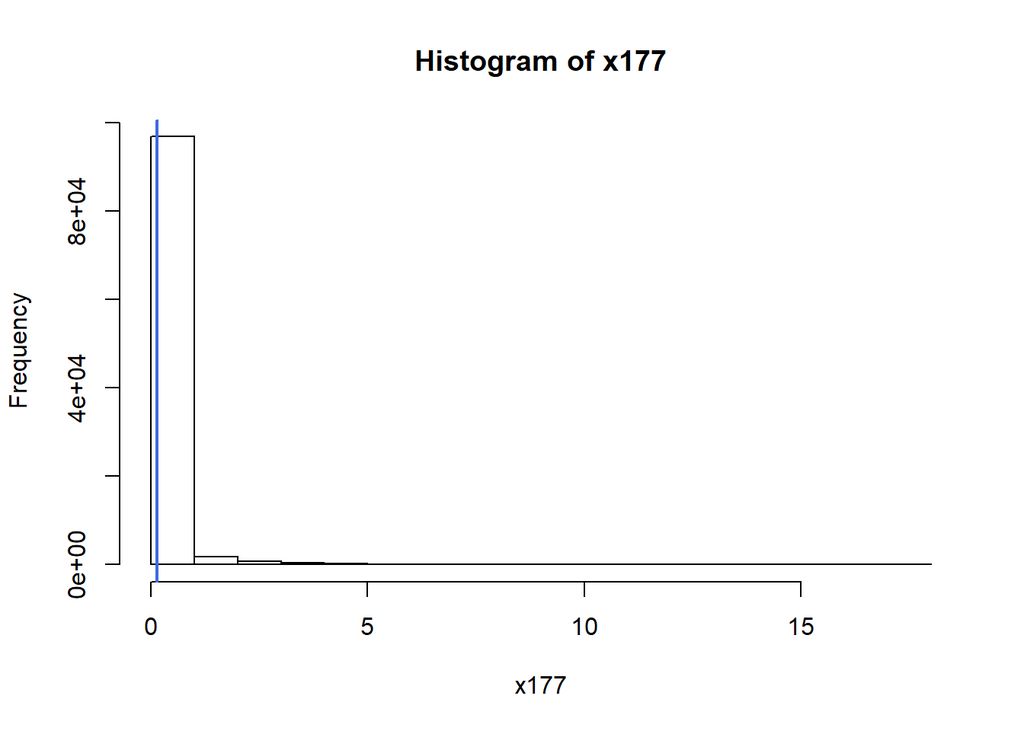

```r
##Now visualize the statistics
##Histogram

hist(data$x177,
    main = "Histogram of x177",
    xlab = "x177")
abline(v =mean(data$x177, na.rm = TRUE),col = "royalblue",
lwd = 2)
```

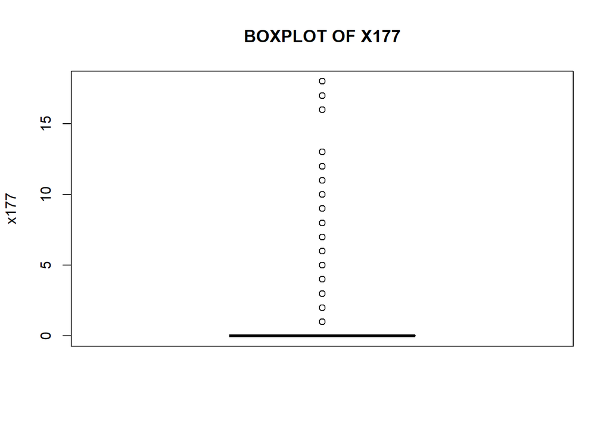

```r
##Boxplot
boxplot(data$x177,
       main = toupper("Boxplot of x177"),
       ylab = "x177",
       col = "blue")
```

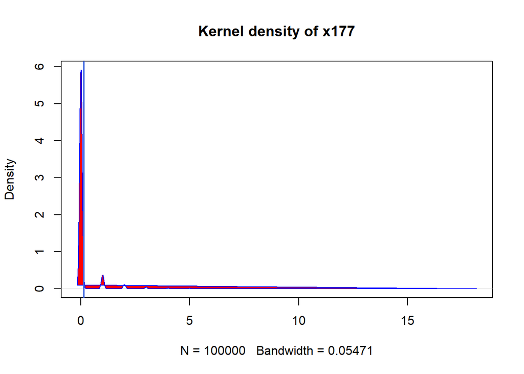

```r
##Density Plot
d <- density(data$x177, na.rm = TRUE)
plot(d, main = "Kernel density of x177")
polygon(d, col = "red", border = "blue")
abline(v =mean(data$x177, na.rm = TRUE),col = "royalblue",
lwd = 2)
```

## There is positive skewness in the data. There are no missing values. This variable have descrete values.

## Variable 178

```r
head(data$x178)
```

```
## [1] 0 0 0 0 1 0
```

```r
## Summary of the data
summary(data$x178)
```

```
##    Min. 1st Qu.  Median    Mean 3rd Qu.    Max.
##  0.0000  0.0000  0.0000  0.1901  0.0000 18.0000
```

##Here we found that mean and median are not pretty close and we can say that the distribution of the variable is not approximately normal

##Missing Values: ##There are no missing values

##Description of the data

```r
#install.packages("psych")

describe(data$x178)
```

```
##    vars     n mean   sd median trimmed mad min max range skew kurtosis se
## X1    1 1e+05 0.19 0.68      0    0.02   0   0  18    18 6.04    56.77  0
```

## Here the kurtosis is very high positive hence there is large data in tail

```r
table(data$x178)
```

```
##
##     0     1     2     3     4     5     6     7     8     9    10    11
## 88747  7187  2265   922   418   224   104    59    30    17    14     6
##    12    13    14    16    17    18
##     2     1     1     1     1     1
```

```r
str(data$x178)
```

```
##  int [1:100000] 0 0 0 0 1 0 0 0 0 0 ...
```

```r
class(data$x178)
```

```
## [1] "integer"
```

## here the all values in integer

```r
##Total number of values excluding NA
NROW(data[which(data$x178<=2),])
```

```
## [1] 98199
```

##i.e;., 98%

```r
NROW(data[which(data$x178<=5),])
```

```
## [1] 99763
```

##i.e;.,99%

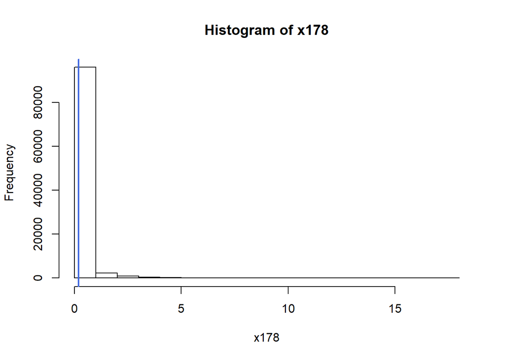

```r
##Now visualize the statistics
##Histogram

hist(data$x178,
    main = "Histogram of x178",
    xlab = "x178")
abline(v =mean(data$x178, na.rm = TRUE),col = "royalblue",
lwd = 2)
```

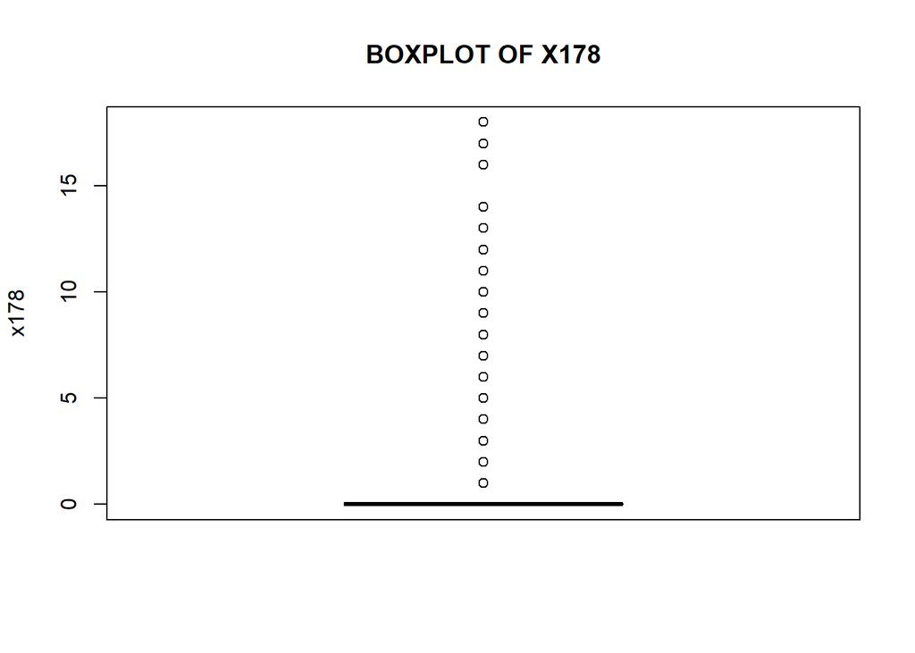

```r
##Boxplot
boxplot(data$x178,
       main = toupper("Boxplot of x178"),
       ylab = "x178",
       col = "blue")
```

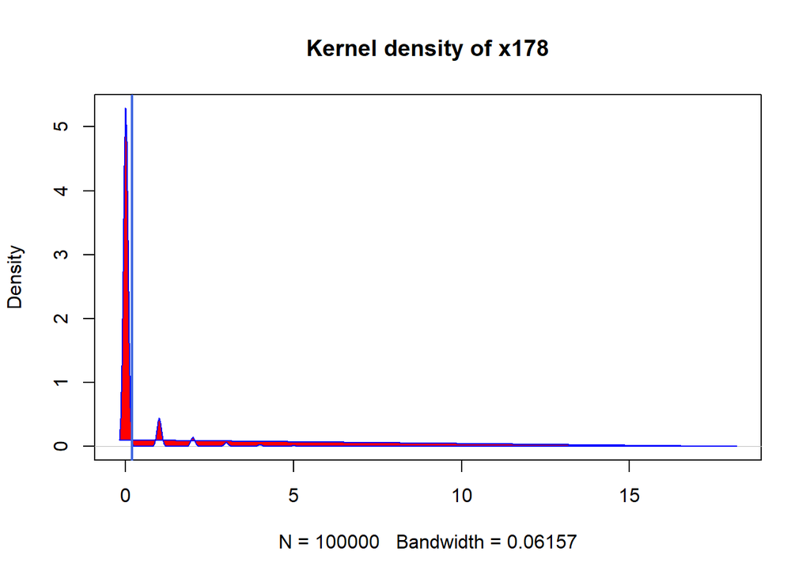

```r
##Density Plot
d <- density(data$x178, na.rm = TRUE)
plot(d, main = "Kernel density of x178")
polygon(d, col = "red", border = "blue")
abline(v =mean(data$x178, na.rm = TRUE),col = "royalblue",
lwd = 2)
```

## Obervation ## From the above graphs and stats i observed that 98% are below 2 and 99% are below 5

## There is positive skewness in the data. There are no missing values. This variable have descrete values.

## Variable 179

```r
head(data$x179)
```

```
## [1] 0 0 3 0 1 0
```

```r
## Summary of the data
summary(data$x179)
```

```
##    Min. 1st Qu.  Median    Mean 3rd Qu.    Max.
##  0.0000  0.0000  0.0000  0.2512  0.0000 18.0000
```

##Here we found that mean and median are not pretty close and we can say that the distribution of the variable is not approximately normal

##Missing Values: ##There are no missing values

##Description of the data

```r
#install.packages("psych")

describe(data$x179)
```

```
##    vars     n mean   sd median trimmed mad min max range skew kurtosis se
## X1    1 1e+05 0.25 0.78      0    0.06   0   0  18    18 5.13    40.44  0
```

## Here the kurtosis is very high positive hence there is large data in tail

```r
table(data$x179)
```

```
##
##     0     1     2     3     4     5     6     7     8     9    10    11
## 85414  9072  3058  1256   569   309   143    83    42    22    14     9
##    12    13    15    16    17    18
##     3     2     1     1     1     1
```

```r
str(data$x179)
```

```
##  int [1:100000] 0 0 3 0 1 0 0 0 0 0 ...
```

```r
class(data$x179)
```

```
## [1] "integer"
```

## here the all values in integer

```r
##Total number of values excluding NA
NROW(data[which(data$x179<=2),])
```

```
## [1] 97544
```

##i.e;., 97%

```r
NROW(data[which(data$x179<=5),])
```

```
## [1] 99678
```

##i.e;.,99%

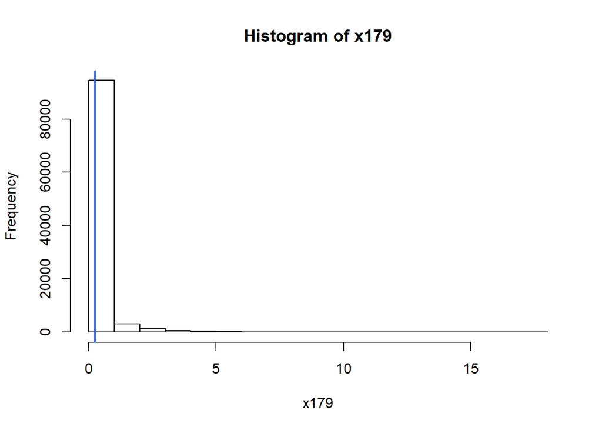

```r
##Now visualize the statistics
##Histogram

hist(data$x179,
    main = "Histogram of x179",
    xlab = "x179")
abline(v =mean(data$x179, na.rm = TRUE),col = "royalblue",
lwd = 2)
```

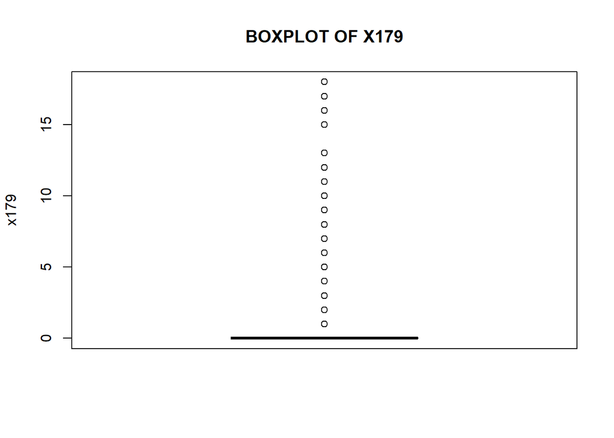

```r
##Boxplot
boxplot(data$x179,
       main = toupper("Boxplot of x179"),
       ylab = "x179",
       col = "blue")
```

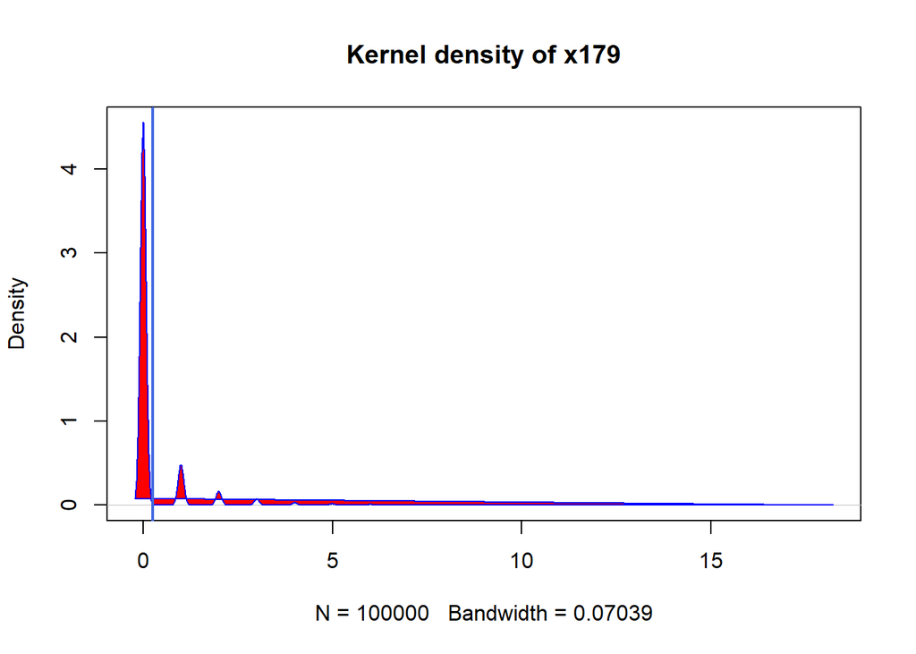

```r
##Density Plot
d <- density(data$x179, na.rm = TRUE)
plot(d, main = "Kernel density of x179")
polygon(d, col = "red", border = "blue")
abline(v =mean(data$x179, na.rm = TRUE),col = "royalblue",
lwd = 2)
```

## Obervation ## From the above graphs and stats i observed that 97% are below 2 and 99% are below 5

## There is positive skewness in the data. There are no missing values. This variable have descrete values.

## Variable 180

```r
head(data$x180)
```

```
## [1] 0 0 0 0 0 0
```

```r
## Summary of the data
summary(data$x180)
```

```
##    Min. 1st Qu.  Median    Mean 3rd Qu.    Max.
## 0.00000 0.00000 0.00000 0.01475 0.00000 1.00000
```

##Here we found that mean and median are not pretty close and we can say that the distribution of the variable is not approximately normal

##Missing Values: ##There are no missing values

##Description of the data

```r
#install.packages("psych")

describe(data$x180)
```

```
##    vars     n mean   sd median trimmed mad min max range skew kurtosis se
## X1    1 1e+05 0.01 0.12      0       0   0   0   1     1 8.05    62.81  0
```

## Here the kurtosis is very high positive hence there is large data in tail

```r
table(data$x180)
```

```
##
##     0     1
## 98525  1475
```

```r
str(data$x180)
```

```
##  int [1:100000] 0 0 0 0 0 0 0 0 0 0 ...
```

```r
class(data$x180)
```

```
## [1] "integer"
```

## here the all values in integer

```r
##Total number of values excluding NA
NROW(data[which(data$x180<=2),])
```

```
## [1] 100000
```

##i.e;., 100%

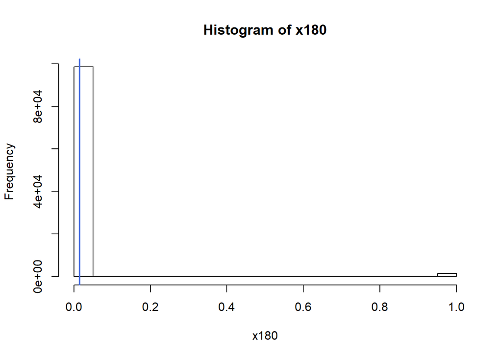

```r
##Now visualize the statistics
##Histogram

hist(data$x180,
    main = "Histogram of x180",
    xlab = "x180")
abline(v =mean(data$x180, na.rm = TRUE),col = "royalblue",
lwd = 2)
```

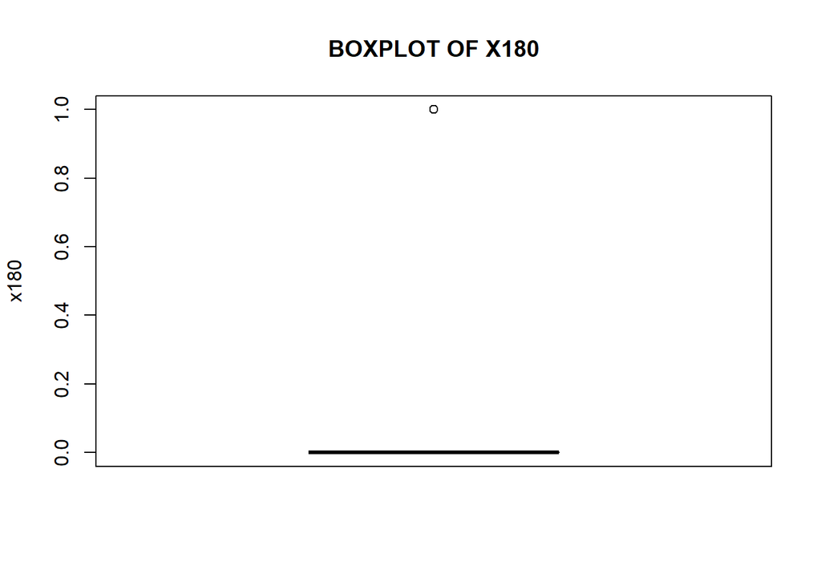

```r
##Boxplot
boxplot(data$x180,
       main = toupper("Boxplot of x180"),
       ylab = "x180",
       col = "blue")
```

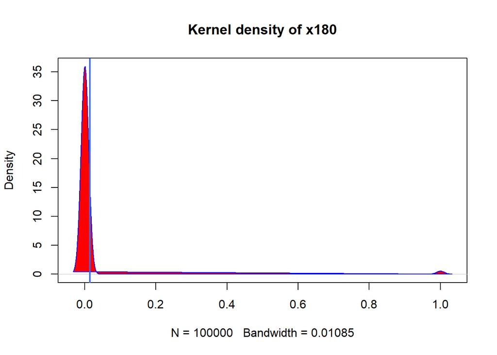

```r
##Density Plot
d <- density(data$x180, na.rm = TRUE)
plot(d, main = "Kernel density of x180")
polygon(d, col = "red", border = "blue")
abline(v =mean(data$x180, na.rm = TRUE),col = "royalblue",
lwd = 2)
```

## Obervation ## From the above graphs and stats i observed that 100% are below 2

## There is positive skewness in the data. There are no missing values. This variable have descrete binomial values.

## Variable 181

```r
head(data$x181)
```

```
## [1] 0 0 0 3 2 1
```

```r
## Summary of the data
summary(data$x181)
```

```
##    Min. 1st Qu.  Median    Mean 3rd Qu.    Max.
##   0.000   0.000   0.000   1.354   2.000  58.000
```

##Here we found that mean and median are not pretty close and we can say that the distribution of the variable is not approximately normal

##Missing Values: ##There are no missing values

##Description of the data

```r
#install.packages("psych")

describe(data$x181)
```

```
##    vars     n mean   sd median trimmed mad min max range skew kurtosis
## X1    1 1e+05 1.35 2.67      0    0.74   0   0  58    58 4.12    27.79
##      se
## X1 0.01
```

## Here the kurtosis is very high positive hence there is large data in tail

```r
table(data$x181)
```

```
##
##     0     1     2     3     4     5     6     7     8     9    10    11
## 56104 17558  9171  5450  3450  2182  1447  1092   830   571   460   315
##    12    13    14    15    16    17    18    19    20    21    22    23
##   271   215   157   124   108   110    72    61    54    44    34    25
##    24    25    26    27    28    29    30    31    32    33    34    35
##    18    10    12     9    13     5     5     4     2     4     1     1
##    36    37    41    42    52    57    58
##     3     3     1     1     1     1     1
```

```r
str(data$x181)
```

```
##  int [1:100000] 0 0 0 3 2 1 0 2 0 6 ...
```

```r
class(data$x181)
```

```
## [1] "integer"
```

## here the all values in integer

```r
##Total number of values excluding NA
NROW(data[which(data$x181<=2),])
```

```
## [1] 82833
```

##i.e;., 82%

```r
NROW(data[which(data$x181<=5),])
```

```
## [1] 93915
```

##i.e;.,93%

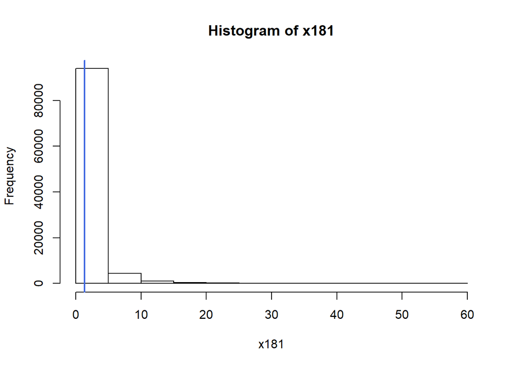

```r
##Now visualize the statistics
##Histogram

hist(data$x181,
    main = "Histogram of x181",
    xlab = "x181")
abline(v =mean(data$x181, na.rm = TRUE),col = "royalblue",
lwd = 2)
```

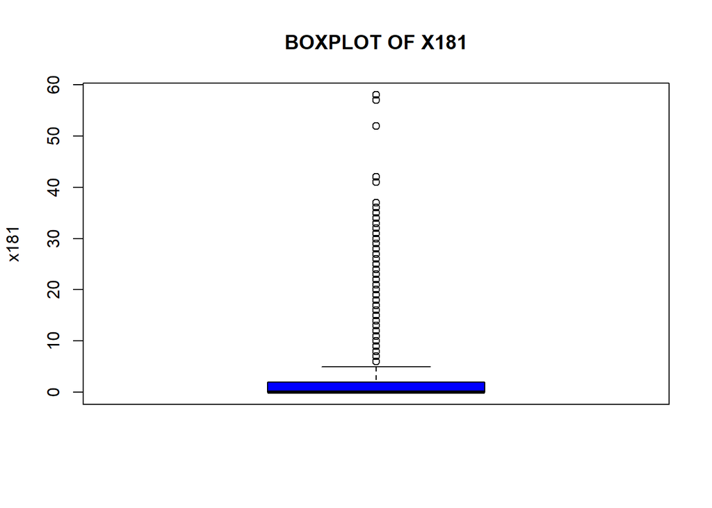

```r
##Boxplot
boxplot(data$x181,
       main = toupper("Boxplot of x181"),
       ylab = "x181",
       col = "blue")
```

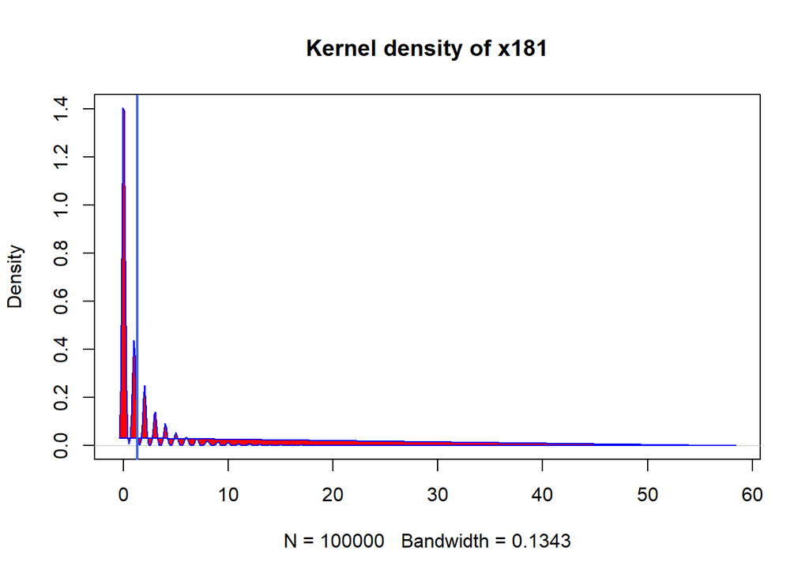

```r
##Density Plot
d <- density(data$x181, na.rm = TRUE)
plot(d, main = "Kernel density of x181")
polygon(d, col = "red", border = "blue")
abline(v =mean(data$x181, na.rm = TRUE),col = "royalblue",
lwd = 2)
```

## Obervation ## From the above graphs and stats i observed that 82% are below 2 and 93% are below 5

## There is positive skewness in the data. There are no missing values. This variable have descrete values.

## Variable 182

```r
head(data$x182)
```

```
## [1] 0 0 0 2 2 1
```

```r
## Summary of the data
summary(data$x182)
```

```
##    Min. 1st Qu.  Median    Mean 3rd Qu.    Max.
##  0.0000  0.0000  0.0000  0.3467  0.0000 15.0000
```

##Here we found that mean and median are not pretty close and we can say that the distribution of the variable is not approximately normal

##Missing Values: ##There are no missing values

##Description of the data

```r
#install.packages("psych")

describe(data$x182)
```

```
##    vars     n mean   sd median trimmed mad min max range skew kurtosis se
## X1    1 1e+05 0.35 0.84      0    0.14   0   0  15    15 3.81    21.67  0
```

## Here the kurtosis is very high positive hence there is large data in tail

```r
table(data$x182)
```

```
##
##     0     1     2     3     4     5     6     7     8     9    10    11
## 78628 13829  4456  1681   762   330   169    71    32    25     7     6
##    12    14    15
##     1     2     1
```

```r
str(data$x182)
```

```
##  int [1:100000] 0 0 0 2 2 1 0 2 0 5 ...
```

```r
class(data$x182)
```

```
## [1] "integer"
```

## here the all values in integer

```r
##Total number of values excluding NA
NROW(data[which(data$x182<=2),])
```

```
## [1] 96913
```

##i.e;., 96%

```r
NROW(data[which(data$x182<=5),])
```

```
## [1] 99686
```

##i.e;.,99%

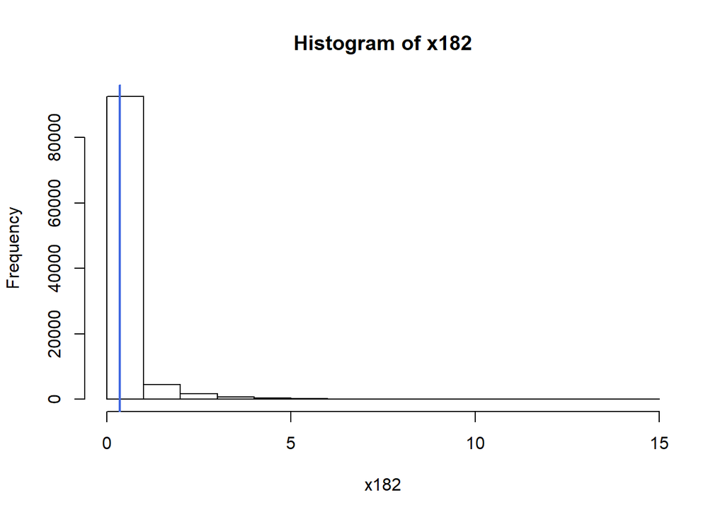

```r
##Now visualize the statistics
##Histogram

hist(data$x182,
    main = "Histogram of x182",
    xlab = "x182")
abline(v =mean(data$x182, na.rm = TRUE),col = "royalblue",
lwd = 2)
```

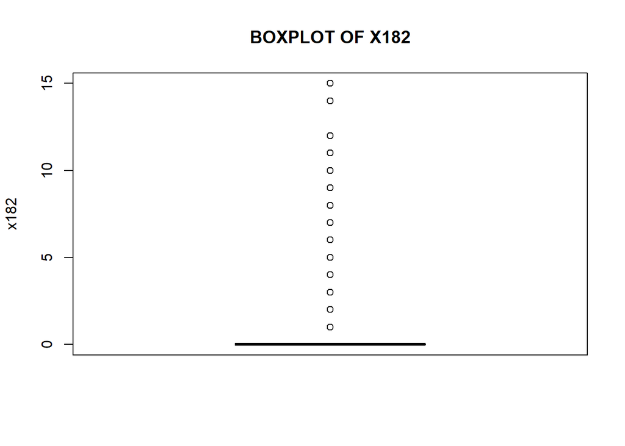

```r
##Boxplot
boxplot(data$x182,
       main = toupper("Boxplot of x182"),
       ylab = "x182",
       col = "blue")
```

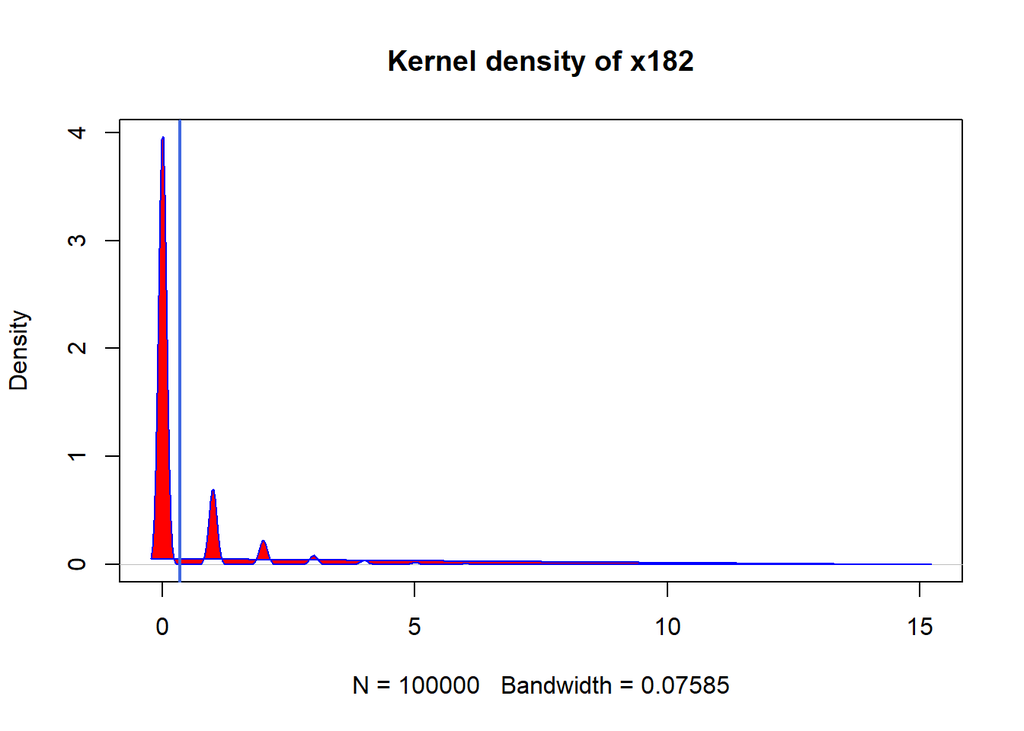

```r
##Density Plot
d <- density(data$x182, na.rm = TRUE)
plot(d, main = "Kernel density of x182")
polygon(d, col = "red", border = "blue")
abline(v =mean(data$x182, na.rm = TRUE),col = "royalblue",
lwd = 2)
```

## Obervation ## From the above graphs and stats i observed that 96% are below 2 and 99% are below 5

## There is positive skewness in the data. There are no missing values. This variable have descrete values.